# SPSS_Output_Homework6Key

[output not shown]

Log  
Log - Log - November 24, 2017

Logistic Regression  
Logistic Regression - Active Dataset - November 24, 2017

[DataSet1] C:\MyGithub\N736Fall2017_Homework6Key_draft\helpmkh.sav

Logistic Regression  
Logistic Regression - Case Processing Summary - November 24, 2017

Case Processing SummaryCase Processing Summary, table, 1 levels of column headers and 2 levels of row headers, table with 4 columns and 8 rows

| Unweighted Cases<sup>a</sup> |  | N | Percent |
| --- | --- | --- | --- |
| Selected Cases | Included in Analysis | 453 | 100.0 |
|  | Missing Cases | 0 | .0 |
|  | Total | 453 | 100.0 |
| Unselected Cases |  | 0 | .0 |
| Total |  | 453 | 100.0 |

a. If weight is in effect, see classification table for the total number of cases.

Logistic Regression  
Logistic Regression - Dependent Variable Encoding - November 24, 2017

Dependent Variable EncodingDependent Variable Encoding, table, 1 levels of column headers and 1 levels of row headers, table with 2 columns and 4 rows

| Original Value | Internal Value |
| --- | --- |
| 0 no | 0 |
| 1 yes | 1 |

Block 0: Beginning Block  
Block 0: Beginning Block - Iteration History - November 24, 2017

Iteration History<sup>a,b,c</sup>Iteration History, table, 2 levels of column headers and 2 levels of row headers, table with 4 columns and 9 rows

| Iteration |  | -2 Log likelihood | Coefficients |
| --- | --- | --- | --- |
|  |  |  | Constant |
| Step 0 | 1 | 537.897 | -.879 |
|  | 2 | 537.518 | -.942 |
|  | 3 | 537.518 | -.943 |

a. Constant is included in the model.  
b. Initial -2 Log Likelihood: 537.518  
c. Estimation terminated at iteration number 3 because parameter estimates changed by less than .001.

Block 0: Beginning Block  
Block 0: Beginning Block - Classification Table - November 24, 2017

Classification Table<sup>a,b</sup>Classification Table, table, 3 levels of column headers and 3 levels of row headers, table with 6 columns and 9 rows

|  | Observed |  | Predicted |  |  |  |
| --- | --- | --- | --- | --- | --- | --- |
|  |  |  | g1b Experienced serious thoughts of suicide (last 30 days) - Baseline |  | Percentage Correct |  |
|  |  |  | 0 no | 1 yes |  |  |
| Step 0 | g1b Experienced serious thoughts of suicide (last 30 days) - Baseline | 0 no | 326 | 0 |  | 100.0 |
|  |  | 1 yes | 127 | 0 | .0 |  |
|  | Overall Percentage |  |  |  | 72.0 |  |

a. Constant is included in the model.  
b. The cut value is .500

Block 0: Beginning Block  
Block 0: Beginning Block - Variables in the Equation - November 24, 2017

Variables in the EquationVariables in the Equation, table, 1 levels of column headers and 2 levels of row headers, table with 8 columns and 3 rows

|  |  | B | S.E. | Wald | df | Sig. | Exp(B) |
| --- | --- | --- | --- | --- | --- | --- | --- |
| Step 0 | Constant | -.943 | .105 | 81.223 | 1 | .000 | .390 |

Block 0: Beginning Block  
Block 0: Beginning Block - Variables not in the Equation - November 24, 2017

Variables not in the EquationVariables not in the Equation, table, 1 levels of column headers and 3 levels of row headers, table with 6 columns and 4 rows

|  |  |  | Score | df | Sig. |
| --- | --- | --- | --- | --- | --- |
| Step 0 | Variables | cesd | 51.346 | 1 | .000 |
|  | Overall Statistics |  | 51.346 | 1 | .000 |

Block 1: Method = Enter  
Block 1: Method = Enter - Iteration History - November 24, 2017

Iteration History<sup>a,b,c,d</sup>Iteration History, table, 2 levels of column headers and 2 levels of row headers, table with 5 columns and 12 rows

| Iteration |  | -2 Log likelihood | Coefficients |  |
| --- | --- | --- | --- | --- |
|  |  |  | Constant | cesd |
| Step 1 | 1 | 488.099 | -2.468 | .048 |
|  | 2 | 481.515 | -3.288 | .068 |
|  | 3 | 481.378 | -3.430 | .071 |
|  | 4 | 481.378 | -3.433 | .071 |
|  | 5 | 481.378 | -3.433 | .071 |

a. Method: Enter  
b. Constant is included in the model.  
c. Initial -2 Log Likelihood: 537.518  
d. Estimation terminated at iteration number 5 because parameter estimates changed by less than .001.

Block 1: Method = Enter  
Block 1: Method = Enter - Omnibus Tests of Model Coefficients - November 24, 2017

Omnibus Tests of Model CoefficientsOmnibus Tests of Model Coefficients, table, 1 levels of column headers and 2 levels of row headers, table with 5 columns and 5 rows

|  |  | Chi-square | df | Sig. |
| --- | --- | --- | --- | --- |
| Step 1 | Step | 56.140 | 1 | .000 |
|  | Block | 56.140 | 1 | .000 |
|  | Model | 56.140 | 1 | .000 |

Block 1: Method = Enter  
Block 1: Method = Enter - Model Summary - November 24, 2017

Model SummaryModel Summary, table, 1 levels of column headers and 1 levels of row headers, table with 4 columns and 4 rows

| Step | -2 Log likelihood | Cox & Snell R Square | Nagelkerke R Square |
| --- | --- | --- | --- |
| 1 | 481.378<sup>a</sup> | .117 | .168 |

a. Estimation terminated at iteration number 5 because parameter estimates changed by less than .001.

Block 1: Method = Enter  
Block 1: Method = Enter - Hosmer and Lemeshow Test - November 24, 2017

Hosmer and Lemeshow TestHosmer and Lemeshow Test, table, 1 levels of column headers and 1 levels of row headers, table with 4 columns and 3 rows

| Step | Chi-square | df | Sig. |
| --- | --- | --- | --- |
| 1 | 17.075 | 8 | .029 |

Block 1: Method = Enter  
Block 1: Method = Enter - Contingency Table for Hosmer and Lemeshow Test - November 24, 2017

Contingency Table for Hosmer and Lemeshow TestContingency Table for Hosmer and Lemeshow Test, table, 2 levels of column headers and 2 levels of row headers, table with 7 columns and 13 rows

|  |  | g1b Experienced serious thoughts of suicide (last 30 days) - Baseline = 0 no |  | g1b Experienced serious thoughts of suicide (last 30 days) - Baseline = 1 yes |  | Total |  |
| --- | --- | --- | --- | --- | --- | --- | --- |
|  |  | Observed | Expected | Observed | Expected |  |  |
| Step 1 | 1 | 46 | 43.117 | 0 | 2.883 |  | 46 |
|  | 2 | 41 | 42.703 | 7 | 5.297 | 48 |  |
|  | 3 | 37 | 39.433 | 10 | 7.567 | 47 |  |
|  | 4 | 34 | 32.720 | 7 | 8.280 | 41 |  |
|  | 5 | 32 | 28.978 | 6 | 9.022 | 38 |  |
|  | 6 | 35 | 32.442 | 10 | 12.558 | 45 |  |
|  | 7 | 30 | 32.460 | 18 | 15.540 | 48 |  |
|  | 8 | 21 | 30.062 | 27 | 17.938 | 48 |  |
|  | 9 | 23 | 22.354 | 18 | 18.646 | 41 |  |
|  | 10 | 27 | 21.730 | 24 | 29.270 | 51 |  |

Block 1: Method = Enter  
Block 1: Method = Enter - Classification Table - November 24, 2017

Classification Table<sup>a</sup>Classification Table, table, 3 levels of column headers and 3 levels of row headers, table with 6 columns and 8 rows

|  | Observed |  | Predicted |  |  |  |
| --- | --- | --- | --- | --- | --- | --- |
|  |  |  | g1b Experienced serious thoughts of suicide (last 30 days) - Baseline |  | Percentage Correct |  |
|  |  |  | 0 no | 1 yes |  |  |
| Step 1 | g1b Experienced serious thoughts of suicide (last 30 days) - Baseline | 0 no | 299 | 27 |  | 91.7 |
|  |  | 1 yes | 103 | 24 | 18.9 |  |
|  | Overall Percentage |  |  |  | 71.3 |  |

a. The cut value is .500

Block 1: Method = Enter  
Block 1: Method = Enter - Variables in the Equation - November 24, 2017

Variables in the EquationVariables in the Equation, table, 2 levels of column headers and 2 levels of row headers, table with 10 columns and 6 rows

|  |  | B | S.E. | Wald | df | Sig. | Exp(B) | 95% C.I.for EXP(B) |  |
| --- | --- | --- | --- | --- | --- | --- | --- | --- | --- |
|  |  |  |  |  |  |  |  | Lower | Upper |
| Step 1<sup>a</sup> | cesd | .071 | .010 | 45.723 | 1 | .000 | 1.073 | 1.052 | 1.096 |
|  | Constant | -3.433 | .404 | 72.097 | 1 | .000 | .032 |  |  |

a. Variable(s) entered on step 1: cesd.

Log  
Log - Log - November 24, 2017

Graph  
Graph - Scatter of PRE_1 cesd - November 24, 2017

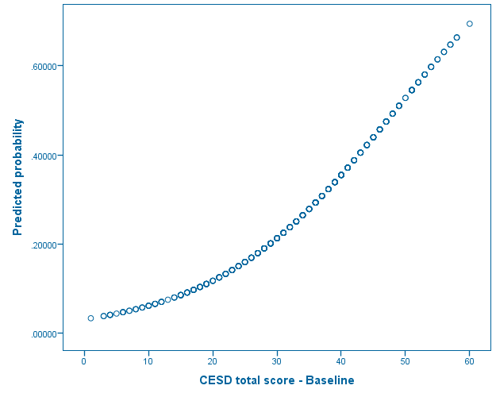

Log  
Log - Log - November 24, 2017

* ============================================.  
* let's look at some other threshold values  
* and we'll compare the classification tables.  
* ============================================.  
LOGISTIC REGRESSION VARIABLES g1b  
/METHOD=ENTER cesd  
/PRINT=GOODFIT ITER(1) CI(95)  
/CRITERIA=PIN(0.05) POUT(0.10) ITERATE(20) CUT(0.2).

Logistic Regression  
Logistic Regression - Case Processing Summary - November 24, 2017

Case Processing SummaryCase Processing Summary, table, 1 levels of column headers and 2 levels of row headers, table with 4 columns and 8 rows

| Unweighted Cases<sup>a</sup> |  | N | Percent |
| --- | --- | --- | --- |
| Selected Cases | Included in Analysis | 453 | 100.0 |
|  | Missing Cases | 0 | .0 |
|  | Total | 453 | 100.0 |
| Unselected Cases |  | 0 | .0 |
| Total |  | 453 | 100.0 |

a. If weight is in effect, see classification table for the total number of cases.

Logistic Regression  
Logistic Regression - Dependent Variable Encoding - November 24, 2017

Dependent Variable EncodingDependent Variable Encoding, table, 1 levels of column headers and 1 levels of row headers, table with 2 columns and 4 rows

| Original Value | Internal Value |
| --- | --- |
| 0 no | 0 |
| 1 yes | 1 |

Block 0: Beginning Block  
Block 0: Beginning Block - Iteration History - November 24, 2017

Iteration History<sup>a,b,c</sup>Iteration History, table, 2 levels of column headers and 2 levels of row headers, table with 4 columns and 9 rows

| Iteration |  | -2 Log likelihood | Coefficients |
| --- | --- | --- | --- |
|  |  |  | Constant |
| Step 0 | 1 | 537.897 | -.879 |
|  | 2 | 537.518 | -.942 |
|  | 3 | 537.518 | -.943 |

a. Constant is included in the model.  
b. Initial -2 Log Likelihood: 537.518  
c. Estimation terminated at iteration number 3 because parameter estimates changed by less than .001.

Block 0: Beginning Block  
Block 0: Beginning Block - Classification Table - November 24, 2017

Classification Table<sup>a,b</sup>Classification Table, table, 3 levels of column headers and 3 levels of row headers, table with 6 columns and 9 rows

|  | Observed |  | Predicted |  |  |  |
| --- | --- | --- | --- | --- | --- | --- |
|  |  |  | g1b Experienced serious thoughts of suicide (last 30 days) - Baseline |  | Percentage Correct |  |
|  |  |  | 0 no | 1 yes |  |  |
| Step 0 | g1b Experienced serious thoughts of suicide (last 30 days) - Baseline | 0 no | 0 | 326 |  | .0 |
|  |  | 1 yes | 0 | 127 | 100.0 |  |
|  | Overall Percentage |  |  |  | 28.0 |  |

a. Constant is included in the model.  
b. The cut value is .200

Block 0: Beginning Block  
Block 0: Beginning Block - Variables in the Equation - November 24, 2017

Variables in the EquationVariables in the Equation, table, 1 levels of column headers and 2 levels of row headers, table with 8 columns and 3 rows

|  |  | B | S.E. | Wald | df | Sig. | Exp(B) |
| --- | --- | --- | --- | --- | --- | --- | --- |
| Step 0 | Constant | -.943 | .105 | 81.223 | 1 | .000 | .390 |

Block 0: Beginning Block  
Block 0: Beginning Block - Variables not in the Equation - November 24, 2017

Variables not in the EquationVariables not in the Equation, table, 1 levels of column headers and 3 levels of row headers, table with 6 columns and 4 rows

|  |  |  | Score | df | Sig. |
| --- | --- | --- | --- | --- | --- |
| Step 0 | Variables | cesd | 51.346 | 1 | .000 |
|  | Overall Statistics |  | 51.346 | 1 | .000 |

Block 1: Method = Enter  
Block 1: Method = Enter - Iteration History - November 24, 2017

Iteration History<sup>a,b,c,d</sup>Iteration History, table, 2 levels of column headers and 2 levels of row headers, table with 5 columns and 12 rows

| Iteration |  | -2 Log likelihood | Coefficients |  |
| --- | --- | --- | --- | --- |
|  |  |  | Constant | cesd |
| Step 1 | 1 | 488.099 | -2.468 | .048 |
|  | 2 | 481.515 | -3.288 | .068 |
|  | 3 | 481.378 | -3.430 | .071 |
|  | 4 | 481.378 | -3.433 | .071 |
|  | 5 | 481.378 | -3.433 | .071 |

a. Method: Enter  
b. Constant is included in the model.  
c. Initial -2 Log Likelihood: 537.518  
d. Estimation terminated at iteration number 5 because parameter estimates changed by less than .001.

Block 1: Method = Enter  
Block 1: Method = Enter - Omnibus Tests of Model Coefficients - November 24, 2017

Omnibus Tests of Model CoefficientsOmnibus Tests of Model Coefficients, table, 1 levels of column headers and 2 levels of row headers, table with 5 columns and 5 rows

|  |  | Chi-square | df | Sig. |
| --- | --- | --- | --- | --- |
| Step 1 | Step | 56.140 | 1 | .000 |
|  | Block | 56.140 | 1 | .000 |
|  | Model | 56.140 | 1 | .000 |

Block 1: Method = Enter  
Block 1: Method = Enter - Model Summary - November 24, 2017

Model SummaryModel Summary, table, 1 levels of column headers and 1 levels of row headers, table with 4 columns and 4 rows

| Step | -2 Log likelihood | Cox & Snell R Square | Nagelkerke R Square |
| --- | --- | --- | --- |
| 1 | 481.378<sup>a</sup> | .117 | .168 |

a. Estimation terminated at iteration number 5 because parameter estimates changed by less than .001.

Block 1: Method = Enter  
Block 1: Method = Enter - Hosmer and Lemeshow Test - November 24, 2017

Hosmer and Lemeshow TestHosmer and Lemeshow Test, table, 1 levels of column headers and 1 levels of row headers, table with 4 columns and 3 rows

| Step | Chi-square | df | Sig. |
| --- | --- | --- | --- |
| 1 | 17.075 | 8 | .029 |

Block 1: Method = Enter  
Block 1: Method = Enter - Contingency Table for Hosmer and Lemeshow Test - November 24, 2017

Contingency Table for Hosmer and Lemeshow TestContingency Table for Hosmer and Lemeshow Test, table, 2 levels of column headers and 2 levels of row headers, table with 7 columns and 13 rows

|  |  | g1b Experienced serious thoughts of suicide (last 30 days) - Baseline = 0 no |  | g1b Experienced serious thoughts of suicide (last 30 days) - Baseline = 1 yes |  | Total |  |
| --- | --- | --- | --- | --- | --- | --- | --- |
|  |  | Observed | Expected | Observed | Expected |  |  |
| Step 1 | 1 | 46 | 43.117 | 0 | 2.883 |  | 46 |
|  | 2 | 41 | 42.703 | 7 | 5.297 | 48 |  |
|  | 3 | 37 | 39.433 | 10 | 7.567 | 47 |  |
|  | 4 | 34 | 32.720 | 7 | 8.280 | 41 |  |
|  | 5 | 32 | 28.978 | 6 | 9.022 | 38 |  |
|  | 6 | 35 | 32.442 | 10 | 12.558 | 45 |  |
|  | 7 | 30 | 32.460 | 18 | 15.540 | 48 |  |
|  | 8 | 21 | 30.062 | 27 | 17.938 | 48 |  |
|  | 9 | 23 | 22.354 | 18 | 18.646 | 41 |  |
|  | 10 | 27 | 21.730 | 24 | 29.270 | 51 |  |

Block 1: Method = Enter  
Block 1: Method = Enter - Classification Table - November 24, 2017

Classification Table<sup>a</sup>Classification Table, table, 3 levels of column headers and 3 levels of row headers, table with 6 columns and 8 rows

|  | Observed |  | Predicted |  |  |  |
| --- | --- | --- | --- | --- | --- | --- |
|  |  |  | g1b Experienced serious thoughts of suicide (last 30 days) - Baseline |  | Percentage Correct |  |
|  |  |  | 0 no | 1 yes |  |  |
| Step 1 | g1b Experienced serious thoughts of suicide (last 30 days) - Baseline | 0 no | 137 | 189 |  | 42.0 |
|  |  | 1 yes | 17 | 110 | 86.6 |  |
|  | Overall Percentage |  |  |  | 54.5 |  |

a. The cut value is .200

Block 1: Method = Enter  
Block 1: Method = Enter - Variables in the Equation - November 24, 2017

Variables in the EquationVariables in the Equation, table, 2 levels of column headers and 2 levels of row headers, table with 10 columns and 6 rows

|  |  | B | S.E. | Wald | df | Sig. | Exp(B) | 95% C.I.for EXP(B) |  |
| --- | --- | --- | --- | --- | --- | --- | --- | --- | --- |
|  |  |  |  |  |  |  |  | Lower | Upper |
| Step 1<sup>a</sup> | cesd | .071 | .010 | 45.723 | 1 | .000 | 1.073 | 1.052 | 1.096 |
|  | Constant | -3.433 | .404 | 72.097 | 1 | .000 | .032 |  |  |

a. Variable(s) entered on step 1: cesd.

Log  
Log - Log - November 24, 2017

LOGISTIC REGRESSION VARIABLES g1b  
/METHOD=ENTER cesd  
/PRINT=GOODFIT ITER(1) CI(95)  
/CRITERIA=PIN(0.05) POUT(0.10) ITERATE(20) CUT(0.4).

Logistic Regression  
Logistic Regression - Case Processing Summary - November 24, 2017

Case Processing SummaryCase Processing Summary, table, 1 levels of column headers and 2 levels of row headers, table with 4 columns and 8 rows

| Unweighted Cases<sup>a</sup> |  | N | Percent |
| --- | --- | --- | --- |
| Selected Cases | Included in Analysis | 453 | 100.0 |
|  | Missing Cases | 0 | .0 |
|  | Total | 453 | 100.0 |
| Unselected Cases |  | 0 | .0 |
| Total |  | 453 | 100.0 |

a. If weight is in effect, see classification table for the total number of cases.

Logistic Regression  
Logistic Regression - Dependent Variable Encoding - November 24, 2017

Dependent Variable EncodingDependent Variable Encoding, table, 1 levels of column headers and 1 levels of row headers, table with 2 columns and 4 rows

| Original Value | Internal Value |
| --- | --- |
| 0 no | 0 |
| 1 yes | 1 |

Block 0: Beginning Block  
Block 0: Beginning Block - Iteration History - November 24, 2017

Iteration History<sup>a,b,c</sup>Iteration History, table, 2 levels of column headers and 2 levels of row headers, table with 4 columns and 9 rows

| Iteration |  | -2 Log likelihood | Coefficients |
| --- | --- | --- | --- |
|  |  |  | Constant |
| Step 0 | 1 | 537.897 | -.879 |
|  | 2 | 537.518 | -.942 |
|  | 3 | 537.518 | -.943 |

a. Constant is included in the model.  
b. Initial -2 Log Likelihood: 537.518  
c. Estimation terminated at iteration number 3 because parameter estimates changed by less than .001.

Block 0: Beginning Block  
Block 0: Beginning Block - Classification Table - November 24, 2017

Classification Table<sup>a,b</sup>Classification Table, table, 3 levels of column headers and 3 levels of row headers, table with 6 columns and 9 rows

|  | Observed |  | Predicted |  |  |  |
| --- | --- | --- | --- | --- | --- | --- |
|  |  |  | g1b Experienced serious thoughts of suicide (last 30 days) - Baseline |  | Percentage Correct |  |
|  |  |  | 0 no | 1 yes |  |  |
| Step 0 | g1b Experienced serious thoughts of suicide (last 30 days) - Baseline | 0 no | 326 | 0 |  | 100.0 |
|  |  | 1 yes | 127 | 0 | .0 |  |
|  | Overall Percentage |  |  |  | 72.0 |  |

a. Constant is included in the model.  
b. The cut value is .400

Block 0: Beginning Block  
Block 0: Beginning Block - Variables in the Equation - November 24, 2017

Variables in the EquationVariables in the Equation, table, 1 levels of column headers and 2 levels of row headers, table with 8 columns and 3 rows

|  |  | B | S.E. | Wald | df | Sig. | Exp(B) |
| --- | --- | --- | --- | --- | --- | --- | --- |
| Step 0 | Constant | -.943 | .105 | 81.223 | 1 | .000 | .390 |

Block 0: Beginning Block  
Block 0: Beginning Block - Variables not in the Equation - November 24, 2017

Variables not in the EquationVariables not in the Equation, table, 1 levels of column headers and 3 levels of row headers, table with 6 columns and 4 rows

|  |  |  | Score | df | Sig. |
| --- | --- | --- | --- | --- | --- |
| Step 0 | Variables | cesd | 51.346 | 1 | .000 |
|  | Overall Statistics |  | 51.346 | 1 | .000 |

Block 1: Method = Enter  
Block 1: Method = Enter - Iteration History - November 24, 2017

Iteration History<sup>a,b,c,d</sup>Iteration History, table, 2 levels of column headers and 2 levels of row headers, table with 5 columns and 12 rows

| Iteration |  | -2 Log likelihood | Coefficients |  |
| --- | --- | --- | --- | --- |
|  |  |  | Constant | cesd |
| Step 1 | 1 | 488.099 | -2.468 | .048 |
|  | 2 | 481.515 | -3.288 | .068 |
|  | 3 | 481.378 | -3.430 | .071 |
|  | 4 | 481.378 | -3.433 | .071 |
|  | 5 | 481.378 | -3.433 | .071 |

a. Method: Enter  
b. Constant is included in the model.  
c. Initial -2 Log Likelihood: 537.518  
d. Estimation terminated at iteration number 5 because parameter estimates changed by less than .001.

Block 1: Method = Enter  
Block 1: Method = Enter - Omnibus Tests of Model Coefficients - November 24, 2017

Omnibus Tests of Model CoefficientsOmnibus Tests of Model Coefficients, table, 1 levels of column headers and 2 levels of row headers, table with 5 columns and 5 rows

|  |  | Chi-square | df | Sig. |
| --- | --- | --- | --- | --- |
| Step 1 | Step | 56.140 | 1 | .000 |
|  | Block | 56.140 | 1 | .000 |
|  | Model | 56.140 | 1 | .000 |

Block 1: Method = Enter  
Block 1: Method = Enter - Model Summary - November 24, 2017

Model SummaryModel Summary, table, 1 levels of column headers and 1 levels of row headers, table with 4 columns and 4 rows

| Step | -2 Log likelihood | Cox & Snell R Square | Nagelkerke R Square |
| --- | --- | --- | --- |
| 1 | 481.378<sup>a</sup> | .117 | .168 |

a. Estimation terminated at iteration number 5 because parameter estimates changed by less than .001.

Block 1: Method = Enter  
Block 1: Method = Enter - Hosmer and Lemeshow Test - November 24, 2017

Hosmer and Lemeshow TestHosmer and Lemeshow Test, table, 1 levels of column headers and 1 levels of row headers, table with 4 columns and 3 rows

| Step | Chi-square | df | Sig. |
| --- | --- | --- | --- |
| 1 | 17.075 | 8 | .029 |

Block 1: Method = Enter  
Block 1: Method = Enter - Contingency Table for Hosmer and Lemeshow Test - November 24, 2017

Contingency Table for Hosmer and Lemeshow TestContingency Table for Hosmer and Lemeshow Test, table, 2 levels of column headers and 2 levels of row headers, table with 7 columns and 13 rows

|  |  | g1b Experienced serious thoughts of suicide (last 30 days) - Baseline = 0 no |  | g1b Experienced serious thoughts of suicide (last 30 days) - Baseline = 1 yes |  | Total |  |
| --- | --- | --- | --- | --- | --- | --- | --- |
|  |  | Observed | Expected | Observed | Expected |  |  |
| Step 1 | 1 | 46 | 43.117 | 0 | 2.883 |  | 46 |
|  | 2 | 41 | 42.703 | 7 | 5.297 | 48 |  |
|  | 3 | 37 | 39.433 | 10 | 7.567 | 47 |  |
|  | 4 | 34 | 32.720 | 7 | 8.280 | 41 |  |
|  | 5 | 32 | 28.978 | 6 | 9.022 | 38 |  |
|  | 6 | 35 | 32.442 | 10 | 12.558 | 45 |  |
|  | 7 | 30 | 32.460 | 18 | 15.540 | 48 |  |
|  | 8 | 21 | 30.062 | 27 | 17.938 | 48 |  |
|  | 9 | 23 | 22.354 | 18 | 18.646 | 41 |  |
|  | 10 | 27 | 21.730 | 24 | 29.270 | 51 |  |

Block 1: Method = Enter  
Block 1: Method = Enter - Classification Table - November 24, 2017

Classification Table<sup>a</sup>Classification Table, table, 3 levels of column headers and 3 levels of row headers, table with 6 columns and 8 rows

|  | Observed |  | Predicted |  |  |  |
| --- | --- | --- | --- | --- | --- | --- |
|  |  |  | g1b Experienced serious thoughts of suicide (last 30 days) - Baseline |  | Percentage Correct |  |
|  |  |  | 0 no | 1 yes |  |  |
| Step 1 | g1b Experienced serious thoughts of suicide (last 30 days) - Baseline | 0 no | 271 | 55 |  | 83.1 |
|  |  | 1 yes | 82 | 45 | 35.4 |  |
|  | Overall Percentage |  |  |  | 69.8 |  |

a. The cut value is .400

Block 1: Method = Enter  
Block 1: Method = Enter - Variables in the Equation - November 24, 2017

Variables in the EquationVariables in the Equation, table, 2 levels of column headers and 2 levels of row headers, table with 10 columns and 6 rows

|  |  | B | S.E. | Wald | df | Sig. | Exp(B) | 95% C.I.for EXP(B) |  |
| --- | --- | --- | --- | --- | --- | --- | --- | --- | --- |
|  |  |  |  |  |  |  |  | Lower | Upper |
| Step 1<sup>a</sup> | cesd | .071 | .010 | 45.723 | 1 | .000 | 1.073 | 1.052 | 1.096 |
|  | Constant | -3.433 | .404 | 72.097 | 1 | .000 | .032 |  |  |

a. Variable(s) entered on step 1: cesd.

Log  
Log - Log - November 24, 2017

LOGISTIC REGRESSION VARIABLES g1b  
/METHOD=ENTER cesd  
/PRINT=GOODFIT ITER(1) CI(95)  
/CRITERIA=PIN(0.05) POUT(0.10) ITERATE(20) CUT(0.6).

Logistic Regression  
Logistic Regression - Case Processing Summary - November 24, 2017

Case Processing SummaryCase Processing Summary, table, 1 levels of column headers and 2 levels of row headers, table with 4 columns and 8 rows

| Unweighted Cases<sup>a</sup> |  | N | Percent |
| --- | --- | --- | --- |
| Selected Cases | Included in Analysis | 453 | 100.0 |
|  | Missing Cases | 0 | .0 |
|  | Total | 453 | 100.0 |
| Unselected Cases |  | 0 | .0 |
| Total |  | 453 | 100.0 |

a. If weight is in effect, see classification table for the total number of cases.

Logistic Regression  
Logistic Regression - Dependent Variable Encoding - November 24, 2017

Dependent Variable EncodingDependent Variable Encoding, table, 1 levels of column headers and 1 levels of row headers, table with 2 columns and 4 rows

| Original Value | Internal Value |
| --- | --- |
| 0 no | 0 |
| 1 yes | 1 |

Block 0: Beginning Block  
Block 0: Beginning Block - Iteration History - November 24, 2017

Iteration History<sup>a,b,c</sup>Iteration History, table, 2 levels of column headers and 2 levels of row headers, table with 4 columns and 9 rows

| Iteration |  | -2 Log likelihood | Coefficients |
| --- | --- | --- | --- |
|  |  |  | Constant |
| Step 0 | 1 | 537.897 | -.879 |
|  | 2 | 537.518 | -.942 |
|  | 3 | 537.518 | -.943 |

a. Constant is included in the model.  
b. Initial -2 Log Likelihood: 537.518  
c. Estimation terminated at iteration number 3 because parameter estimates changed by less than .001.

Block 0: Beginning Block  
Block 0: Beginning Block - Classification Table - November 24, 2017

Classification Table<sup>a,b</sup>Classification Table, table, 3 levels of column headers and 3 levels of row headers, table with 6 columns and 9 rows

|  | Observed |  | Predicted |  |  |  |
| --- | --- | --- | --- | --- | --- | --- |
|  |  |  | g1b Experienced serious thoughts of suicide (last 30 days) - Baseline |  | Percentage Correct |  |
|  |  |  | 0 no | 1 yes |  |  |
| Step 0 | g1b Experienced serious thoughts of suicide (last 30 days) - Baseline | 0 no | 326 | 0 |  | 100.0 |
|  |  | 1 yes | 127 | 0 | .0 |  |
|  | Overall Percentage |  |  |  | 72.0 |  |

a. Constant is included in the model.  
b. The cut value is .600

Block 0: Beginning Block  
Block 0: Beginning Block - Variables in the Equation - November 24, 2017

Variables in the EquationVariables in the Equation, table, 1 levels of column headers and 2 levels of row headers, table with 8 columns and 3 rows

|  |  | B | S.E. | Wald | df | Sig. | Exp(B) |
| --- | --- | --- | --- | --- | --- | --- | --- |
| Step 0 | Constant | -.943 | .105 | 81.223 | 1 | .000 | .390 |

Block 0: Beginning Block  
Block 0: Beginning Block - Variables not in the Equation - November 24, 2017

Variables not in the EquationVariables not in the Equation, table, 1 levels of column headers and 3 levels of row headers, table with 6 columns and 4 rows

|  |  |  | Score | df | Sig. |
| --- | --- | --- | --- | --- | --- |
| Step 0 | Variables | cesd | 51.346 | 1 | .000 |
|  | Overall Statistics |  | 51.346 | 1 | .000 |

Block 1: Method = Enter  
Block 1: Method = Enter - Iteration History - November 24, 2017

Iteration History<sup>a,b,c,d</sup>Iteration History, table, 2 levels of column headers and 2 levels of row headers, table with 5 columns and 12 rows

| Iteration |  | -2 Log likelihood | Coefficients |  |
| --- | --- | --- | --- | --- |
|  |  |  | Constant | cesd |
| Step 1 | 1 | 488.099 | -2.468 | .048 |
|  | 2 | 481.515 | -3.288 | .068 |
|  | 3 | 481.378 | -3.430 | .071 |
|  | 4 | 481.378 | -3.433 | .071 |
|  | 5 | 481.378 | -3.433 | .071 |

a. Method: Enter  
b. Constant is included in the model.  
c. Initial -2 Log Likelihood: 537.518  
d. Estimation terminated at iteration number 5 because parameter estimates changed by less than .001.

Block 1: Method = Enter  
Block 1: Method = Enter - Omnibus Tests of Model Coefficients - November 24, 2017

Omnibus Tests of Model CoefficientsOmnibus Tests of Model Coefficients, table, 1 levels of column headers and 2 levels of row headers, table with 5 columns and 5 rows

|  |  | Chi-square | df | Sig. |
| --- | --- | --- | --- | --- |
| Step 1 | Step | 56.140 | 1 | .000 |
|  | Block | 56.140 | 1 | .000 |
|  | Model | 56.140 | 1 | .000 |

Block 1: Method = Enter  
Block 1: Method = Enter - Model Summary - November 24, 2017

Model SummaryModel Summary, table, 1 levels of column headers and 1 levels of row headers, table with 4 columns and 4 rows

| Step | -2 Log likelihood | Cox & Snell R Square | Nagelkerke R Square |
| --- | --- | --- | --- |
| 1 | 481.378<sup>a</sup> | .117 | .168 |

a. Estimation terminated at iteration number 5 because parameter estimates changed by less than .001.

Block 1: Method = Enter  
Block 1: Method = Enter - Hosmer and Lemeshow Test - November 24, 2017

Hosmer and Lemeshow TestHosmer and Lemeshow Test, table, 1 levels of column headers and 1 levels of row headers, table with 4 columns and 3 rows

| Step | Chi-square | df | Sig. |
| --- | --- | --- | --- |
| 1 | 17.075 | 8 | .029 |

Block 1: Method = Enter  
Block 1: Method = Enter - Contingency Table for Hosmer and Lemeshow Test - November 24, 2017

Contingency Table for Hosmer and Lemeshow TestContingency Table for Hosmer and Lemeshow Test, table, 2 levels of column headers and 2 levels of row headers, table with 7 columns and 13 rows

|  |  | g1b Experienced serious thoughts of suicide (last 30 days) - Baseline = 0 no |  | g1b Experienced serious thoughts of suicide (last 30 days) - Baseline = 1 yes |  | Total |  |
| --- | --- | --- | --- | --- | --- | --- | --- |
|  |  | Observed | Expected | Observed | Expected |  |  |
| Step 1 | 1 | 46 | 43.117 | 0 | 2.883 |  | 46 |
|  | 2 | 41 | 42.703 | 7 | 5.297 | 48 |  |
|  | 3 | 37 | 39.433 | 10 | 7.567 | 47 |  |
|  | 4 | 34 | 32.720 | 7 | 8.280 | 41 |  |
|  | 5 | 32 | 28.978 | 6 | 9.022 | 38 |  |
|  | 6 | 35 | 32.442 | 10 | 12.558 | 45 |  |
|  | 7 | 30 | 32.460 | 18 | 15.540 | 48 |  |
|  | 8 | 21 | 30.062 | 27 | 17.938 | 48 |  |
|  | 9 | 23 | 22.354 | 18 | 18.646 | 41 |  |
|  | 10 | 27 | 21.730 | 24 | 29.270 | 51 |  |

Block 1: Method = Enter  
Block 1: Method = Enter - Classification Table - November 24, 2017

Classification Table<sup>a</sup>Classification Table, table, 3 levels of column headers and 3 levels of row headers, table with 6 columns and 8 rows

|  | Observed |  | Predicted |  |  |  |
| --- | --- | --- | --- | --- | --- | --- |
|  |  |  | g1b Experienced serious thoughts of suicide (last 30 days) - Baseline |  | Percentage Correct |  |
|  |  |  | 0 no | 1 yes |  |  |
| Step 1 | g1b Experienced serious thoughts of suicide (last 30 days) - Baseline | 0 no | 322 | 4 |  | 98.8 |
|  |  | 1 yes | 118 | 9 | 7.1 |  |
|  | Overall Percentage |  |  |  | 73.1 |  |

a. The cut value is .600

Block 1: Method = Enter  
Block 1: Method = Enter - Variables in the Equation - November 24, 2017

Variables in the EquationVariables in the Equation, table, 2 levels of column headers and 2 levels of row headers, table with 10 columns and 6 rows

|  |  | B | S.E. | Wald | df | Sig. | Exp(B) | 95% C.I.for EXP(B) |  |
| --- | --- | --- | --- | --- | --- | --- | --- | --- | --- |
|  |  |  |  |  |  |  |  | Lower | Upper |
| Step 1<sup>a</sup> | cesd | .071 | .010 | 45.723 | 1 | .000 | 1.073 | 1.052 | 1.096 |
|  | Constant | -3.433 | .404 | 72.097 | 1 | .000 | .032 |  |  |

a. Variable(s) entered on step 1: cesd.

Log  
Log - Log - November 24, 2017

LOGISTIC REGRESSION VARIABLES g1b  
/METHOD=ENTER cesd  
/PRINT=GOODFIT ITER(1) CI(95)  
/CRITERIA=PIN(0.05) POUT(0.10) ITERATE(20) CUT(0.8).

Logistic Regression  
Logistic Regression - Case Processing Summary - November 24, 2017

Case Processing SummaryCase Processing Summary, table, 1 levels of column headers and 2 levels of row headers, table with 4 columns and 8 rows

| Unweighted Cases<sup>a</sup> |  | N | Percent |
| --- | --- | --- | --- |
| Selected Cases | Included in Analysis | 453 | 100.0 |
|  | Missing Cases | 0 | .0 |
|  | Total | 453 | 100.0 |
| Unselected Cases |  | 0 | .0 |
| Total |  | 453 | 100.0 |

a. If weight is in effect, see classification table for the total number of cases.

Logistic Regression  
Logistic Regression - Dependent Variable Encoding - November 24, 2017

Dependent Variable EncodingDependent Variable Encoding, table, 1 levels of column headers and 1 levels of row headers, table with 2 columns and 4 rows

| Original Value | Internal Value |
| --- | --- |
| 0 no | 0 |
| 1 yes | 1 |

Block 0: Beginning Block  
Block 0: Beginning Block - Iteration History - November 24, 2017

Iteration History<sup>a,b,c</sup>Iteration History, table, 2 levels of column headers and 2 levels of row headers, table with 4 columns and 9 rows

| Iteration |  | -2 Log likelihood | Coefficients |
| --- | --- | --- | --- |
|  |  |  | Constant |
| Step 0 | 1 | 537.897 | -.879 |
|  | 2 | 537.518 | -.942 |
|  | 3 | 537.518 | -.943 |

a. Constant is included in the model.  
b. Initial -2 Log Likelihood: 537.518  
c. Estimation terminated at iteration number 3 because parameter estimates changed by less than .001.

Block 0: Beginning Block  
Block 0: Beginning Block - Classification Table - November 24, 2017

Classification Table<sup>a,b</sup>Classification Table, table, 3 levels of column headers and 3 levels of row headers, table with 6 columns and 9 rows

|  | Observed |  | Predicted |  |  |  |
| --- | --- | --- | --- | --- | --- | --- |
|  |  |  | g1b Experienced serious thoughts of suicide (last 30 days) - Baseline |  | Percentage Correct |  |
|  |  |  | 0 no | 1 yes |  |  |
| Step 0 | g1b Experienced serious thoughts of suicide (last 30 days) - Baseline | 0 no | 326 | 0 |  | 100.0 |
|  |  | 1 yes | 127 | 0 | .0 |  |
|  | Overall Percentage |  |  |  | 72.0 |  |

a. Constant is included in the model.  
b. The cut value is .800

Block 0: Beginning Block  
Block 0: Beginning Block - Variables in the Equation - November 24, 2017

Variables in the EquationVariables in the Equation, table, 1 levels of column headers and 2 levels of row headers, table with 8 columns and 3 rows

|  |  | B | S.E. | Wald | df | Sig. | Exp(B) |
| --- | --- | --- | --- | --- | --- | --- | --- |
| Step 0 | Constant | -.943 | .105 | 81.223 | 1 | .000 | .390 |

Block 0: Beginning Block  
Block 0: Beginning Block - Variables not in the Equation - November 24, 2017

Variables not in the EquationVariables not in the Equation, table, 1 levels of column headers and 3 levels of row headers, table with 6 columns and 4 rows

|  |  |  | Score | df | Sig. |
| --- | --- | --- | --- | --- | --- |
| Step 0 | Variables | cesd | 51.346 | 1 | .000 |
|  | Overall Statistics |  | 51.346 | 1 | .000 |

Block 1: Method = Enter  
Block 1: Method = Enter - Iteration History - November 24, 2017

Iteration History<sup>a,b,c,d</sup>Iteration History, table, 2 levels of column headers and 2 levels of row headers, table with 5 columns and 12 rows

| Iteration |  | -2 Log likelihood | Coefficients |  |
| --- | --- | --- | --- | --- |
|  |  |  | Constant | cesd |
| Step 1 | 1 | 488.099 | -2.468 | .048 |
|  | 2 | 481.515 | -3.288 | .068 |
|  | 3 | 481.378 | -3.430 | .071 |
|  | 4 | 481.378 | -3.433 | .071 |
|  | 5 | 481.378 | -3.433 | .071 |

a. Method: Enter  
b. Constant is included in the model.  
c. Initial -2 Log Likelihood: 537.518  
d. Estimation terminated at iteration number 5 because parameter estimates changed by less than .001.

Block 1: Method = Enter  
Block 1: Method = Enter - Omnibus Tests of Model Coefficients - November 24, 2017

Omnibus Tests of Model CoefficientsOmnibus Tests of Model Coefficients, table, 1 levels of column headers and 2 levels of row headers, table with 5 columns and 5 rows

|  |  | Chi-square | df | Sig. |
| --- | --- | --- | --- | --- |
| Step 1 | Step | 56.140 | 1 | .000 |
|  | Block | 56.140 | 1 | .000 |
|  | Model | 56.140 | 1 | .000 |

Block 1: Method = Enter  
Block 1: Method = Enter - Model Summary - November 24, 2017

Model SummaryModel Summary, table, 1 levels of column headers and 1 levels of row headers, table with 4 columns and 4 rows

| Step | -2 Log likelihood | Cox & Snell R Square | Nagelkerke R Square |
| --- | --- | --- | --- |
| 1 | 481.378<sup>a</sup> | .117 | .168 |

a. Estimation terminated at iteration number 5 because parameter estimates changed by less than .001.

Block 1: Method = Enter  
Block 1: Method = Enter - Hosmer and Lemeshow Test - November 24, 2017

Hosmer and Lemeshow TestHosmer and Lemeshow Test, table, 1 levels of column headers and 1 levels of row headers, table with 4 columns and 3 rows

| Step | Chi-square | df | Sig. |
| --- | --- | --- | --- |
| 1 | 17.075 | 8 | .029 |

Block 1: Method = Enter  
Block 1: Method = Enter - Contingency Table for Hosmer and Lemeshow Test - November 24, 2017

Contingency Table for Hosmer and Lemeshow TestContingency Table for Hosmer and Lemeshow Test, table, 2 levels of column headers and 2 levels of row headers, table with 7 columns and 13 rows

|  |  | g1b Experienced serious thoughts of suicide (last 30 days) - Baseline = 0 no |  | g1b Experienced serious thoughts of suicide (last 30 days) - Baseline = 1 yes |  | Total |  |
| --- | --- | --- | --- | --- | --- | --- | --- |
|  |  | Observed | Expected | Observed | Expected |  |  |
| Step 1 | 1 | 46 | 43.117 | 0 | 2.883 |  | 46 |
|  | 2 | 41 | 42.703 | 7 | 5.297 | 48 |  |
|  | 3 | 37 | 39.433 | 10 | 7.567 | 47 |  |
|  | 4 | 34 | 32.720 | 7 | 8.280 | 41 |  |
|  | 5 | 32 | 28.978 | 6 | 9.022 | 38 |  |
|  | 6 | 35 | 32.442 | 10 | 12.558 | 45 |  |
|  | 7 | 30 | 32.460 | 18 | 15.540 | 48 |  |
|  | 8 | 21 | 30.062 | 27 | 17.938 | 48 |  |
|  | 9 | 23 | 22.354 | 18 | 18.646 | 41 |  |
|  | 10 | 27 | 21.730 | 24 | 29.270 | 51 |  |

Block 1: Method = Enter  
Block 1: Method = Enter - Classification Table - November 24, 2017

Classification Table<sup>a</sup>Classification Table, table, 3 levels of column headers and 3 levels of row headers, table with 6 columns and 8 rows

|  | Observed |  | Predicted |  |  |  |
| --- | --- | --- | --- | --- | --- | --- |
|  |  |  | g1b Experienced serious thoughts of suicide (last 30 days) - Baseline |  | Percentage Correct |  |
|  |  |  | 0 no | 1 yes |  |  |
| Step 1 | g1b Experienced serious thoughts of suicide (last 30 days) - Baseline | 0 no | 326 | 0 |  | 100.0 |
|  |  | 1 yes | 127 | 0 | .0 |  |
|  | Overall Percentage |  |  |  | 72.0 |  |

a. The cut value is .800

Block 1: Method = Enter  
Block 1: Method = Enter - Variables in the Equation - November 24, 2017

Variables in the EquationVariables in the Equation, table, 2 levels of column headers and 2 levels of row headers, table with 10 columns and 6 rows

|  |  | B | S.E. | Wald | df | Sig. | Exp(B) | 95% C.I.for EXP(B) |  |
| --- | --- | --- | --- | --- | --- | --- | --- | --- | --- |
|  |  |  |  |  |  |  |  | Lower | Upper |
| Step 1<sup>a</sup> | cesd | .071 | .010 | 45.723 | 1 | .000 | 1.073 | 1.052 | 1.096 |
|  | Constant | -3.433 | .404 | 72.097 | 1 | .000 | .032 |  |  |

a. Variable(s) entered on step 1: cesd.

Log  
Log - Log - November 24, 2017

ROC Curve  
ROC Curve - Case Processing Summary - November 24, 2017

Case Processing SummaryCase Processing Summary, table, 1 levels of column headers and 1 levels of row headers, table with 2 columns and 6 rows

| g1b Experienced serious thoughts of suicide (last 30 days) - Baseline | Valid N (listwise) |
| --- | --- |
| Positive<sup>a</sup> | 127 |
| Negative | 326 |

Larger values of the test result variable(s) indicate stronger evidence for a positive actual state.  
a. The positive actual state is 1 yes.

ROC Curve  
ROC Curve - ROC Curve - November 24, 2017

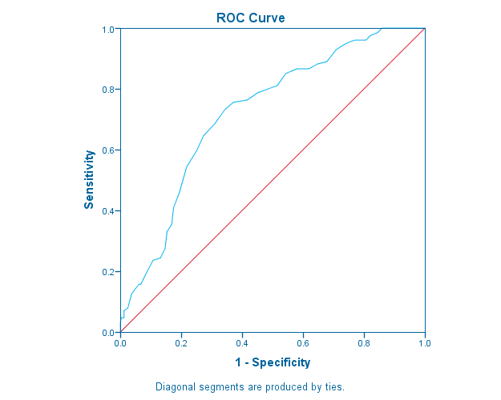

ROC Curve  
ROC Curve - Area Under the Curve - November 24, 2017

Area Under the CurveArea Under the Curve, table, Test Result Variable(s), cesd CESD total score - Baseline, 1 layers, 2 levels of column headers and 0 levels of row headers, table with 5 columns and 8 rows

| cesd CESD total score - Baseline cesd CESD total score - Baseline |  |  |  |  |
| --- | --- | --- | --- | --- |
| Area | Std. Error<sup>a</sup> | Asymptotic Sig.<sup>b</sup> | Asymptotic 95% Confidence Interval |  |
|  |  |  | Lower Bound | Upper Bound |
| .723 | .025 | .000 | .673 | .773 |

The test result variable(s): cesd CESD total score - Baseline has at least one tie between the positive actual state group and the negative actual state group. Statistics may be biased.  
a. Under the nonparametric assumption  
b. Null hypothesis: true area = 0.5

ROC Curve  
ROC Curve - Coordinates of the Curve - November 24, 2017

Coordinates of the CurveCoordinates of the Curve, table, Test Result Variable(s), cesd CESD total score - Baseline, 1 layers, 1 levels of column headers and 0 levels of row headers, table with 3 columns and 64 rows

| cesd CESD total score - Baseline cesd CESD total score - Baseline |  |  |
| --- | --- | --- |
| Positive if Greater Than or Equal To<sup>a</sup> | Sensitivity | 1 - Specificity |
| .00 | 1.000 | 1.000 |
| 2.00 | 1.000 | .997 |
| 3.50 | 1.000 | .991 |
| 4.50 | 1.000 | .979 |
| 5.50 | 1.000 | .975 |
| 6.50 | 1.000 | .963 |
| 7.50 | 1.000 | .957 |
| 8.50 | 1.000 | .948 |
| 9.50 | 1.000 | .939 |
| 10.50 | 1.000 | .926 |
| 11.50 | 1.000 | .911 |
| 12.50 | 1.000 | .899 |
| 13.50 | 1.000 | .896 |
| 14.50 | 1.000 | .887 |
| 15.50 | 1.000 | .859 |
| 16.50 | .984 | .844 |
| 17.50 | .976 | .822 |
| 18.50 | .961 | .807 |
| 19.50 | .961 | .782 |
| 20.50 | .961 | .770 |
| 21.50 | .953 | .748 |
| 22.50 | .945 | .733 |
| 23.50 | .929 | .709 |
| 24.50 | .906 | .690 |
| 25.50 | .890 | .678 |
| 26.50 | .882 | .647 |
| 27.50 | .866 | .620 |
| 28.50 | .866 | .580 |
| 29.50 | .850 | .543 |
| 30.50 | .811 | .515 |
| 31.50 | .795 | .472 |
| 32.50 | .787 | .451 |
| 33.50 | .764 | .417 |
| 34.50 | .756 | .371 |
| 35.50 | .732 | .344 |
| 36.50 | .685 | .310 |
| 37.50 | .646 | .273 |
| 38.50 | .598 | .252 |
| 39.50 | .543 | .218 |
| 40.50 | .457 | .193 |
| 41.50 | .409 | .175 |
| 42.50 | .354 | .169 |
| 43.50 | .331 | .153 |
| 44.50 | .276 | .147 |
| 45.50 | .244 | .132 |
| 46.50 | .236 | .107 |
| 47.50 | .213 | .095 |
| 48.50 | .189 | .083 |
| 49.50 | .157 | .067 |
| 50.50 | .157 | .061 |
| 51.50 | .126 | .037 |
| 52.50 | .102 | .031 |
| 53.50 | .079 | .025 |
| 54.50 | .071 | .012 |
| 55.50 | .047 | .012 |
| 56.50 | .047 | .003 |
| 57.50 | .031 | .000 |
| 59.00 | .008 | .000 |
| 61.00 | .000 | .000 |

The test result variable(s): cesd CESD total score - Baseline has at least one tie between the positive actual state group and the negative actual state group.  
a. The smallest cutoff value is the minimum observed test value minus 1, and the largest cutoff value is the maximum observed test value plus 1. All the other cutoff values are the averages of two consecutive ordered observed test values.

Log  
Log - Log - November 24, 2017

Logistic Regression  
Logistic Regression - Case Processing Summary - November 24, 2017

Case Processing SummaryCase Processing Summary, table, 1 levels of column headers and 2 levels of row headers, table with 4 columns and 8 rows

| Unweighted Cases<sup>a</sup> |  | N | Percent |
| --- | --- | --- | --- |
| Selected Cases | Included in Analysis | 453 | 100.0 |
|  | Missing Cases | 0 | .0 |
|  | Total | 453 | 100.0 |
| Unselected Cases |  | 0 | .0 |
| Total |  | 453 | 100.0 |

a. If weight is in effect, see classification table for the total number of cases.

Logistic Regression  
Logistic Regression - Dependent Variable Encoding - November 24, 2017

Dependent Variable EncodingDependent Variable Encoding, table, 1 levels of column headers and 1 levels of row headers, table with 2 columns and 4 rows

| Original Value | Internal Value |
| --- | --- |
| 0 no | 0 |
| 1 yes | 1 |

Block 0: Beginning Block  
Block 0: Beginning Block - Iteration History - November 24, 2017

Iteration History<sup>a,b,c</sup>Iteration History, table, 2 levels of column headers and 2 levels of row headers, table with 4 columns and 9 rows

| Iteration |  | -2 Log likelihood | Coefficients |
| --- | --- | --- | --- |
|  |  |  | Constant |
| Step 0 | 1 | 537.897 | -.879 |
|  | 2 | 537.518 | -.942 |
|  | 3 | 537.518 | -.943 |

a. Constant is included in the model.  
b. Initial -2 Log Likelihood: 537.518  
c. Estimation terminated at iteration number 3 because parameter estimates changed by less than .001.

Block 0: Beginning Block  
Block 0: Beginning Block - Classification Table - November 24, 2017

Classification Table<sup>a,b</sup>Classification Table, table, 3 levels of column headers and 3 levels of row headers, table with 6 columns and 9 rows

|  | Observed |  | Predicted |  |  |  |
| --- | --- | --- | --- | --- | --- | --- |
|  |  |  | g1b Experienced serious thoughts of suicide (last 30 days) - Baseline |  | Percentage Correct |  |
|  |  |  | 0 no | 1 yes |  |  |
| Step 0 | g1b Experienced serious thoughts of suicide (last 30 days) - Baseline | 0 no | 326 | 0 |  | 100.0 |
|  |  | 1 yes | 127 | 0 | .0 |  |
|  | Overall Percentage |  |  |  | 72.0 |  |

a. Constant is included in the model.  
b. The cut value is .500

Block 0: Beginning Block  
Block 0: Beginning Block - Variables in the Equation - November 24, 2017

Variables in the EquationVariables in the Equation, table, 1 levels of column headers and 2 levels of row headers, table with 8 columns and 3 rows

|  |  | B | S.E. | Wald | df | Sig. | Exp(B) |
| --- | --- | --- | --- | --- | --- | --- | --- |
| Step 0 | Constant | -.943 | .105 | 81.223 | 1 | .000 | .390 |

Block 0: Beginning Block  
Block 0: Beginning Block - Variables not in the Equation - November 24, 2017

Variables not in the EquationVariables not in the Equation, table, 1 levels of column headers and 3 levels of row headers, table with 6 columns and 11 rows

|  |  |  | Score | df | Sig. |
| --- | --- | --- | --- | --- | --- |
| Step 0 | Variables | age | 1.428 | 1 | .232 |
|  |  | female | 10.253 | 1 | .001 |
|  |  | pss_fr | 3.733 | 1 | .053 |
|  |  | homeless | 7.913 | 1 | .005 |
|  |  | pcs | 9.866 | 1 | .002 |
|  |  | mcs | 45.134 | 1 | .000 |
|  |  | cesd | 51.346 | 1 | .000 |
|  |  | indtot | 13.236 | 1 | .000 |
|  | Overall Statistics |  | 72.276 | 8 | .000 |

Block 1: Method = Forward Stepwise (Likelihood Ratio)  
Block 1: Method = Forward Stepwise (Likelihood Ratio) - Iteration History - November 24, 2017

Iteration History<sup>a,b,c,d,e</sup>Iteration History, table, 2 levels of column headers and 2 levels of row headers, table with 8 columns and 27 rows

| Iteration |  | -2 Log likelihood | Coefficients |  |  |  |  |
| --- | --- | --- | --- | --- | --- | --- | --- |
|  |  |  | Constant | cesd | mcs | homeless | female |
| Step 1 | 1 | 488.099 | -2.468 | .048 |  |  |  |
|  | 2 | 481.515 | -3.288 | .068 |  |  |  |
|  | 3 | 481.378 | -3.430 | .071 |  |  |  |
|  | 4 | 481.378 | -3.433 | .071 |  |  |  |
|  | 5 | 481.378 | -3.433 | .071 |  |  |  |
| Step 2 | 1 | 481.534 | -1.236 | .033 | -.023 |  |  |
|  | 2 | 472.928 | -1.511 | .046 | -.034 |  |  |
|  | 3 | 472.661 | -1.549 | .048 | -.037 |  |  |
|  | 4 | 472.661 | -1.550 | .048 | -.037 |  |  |
| Step 3 | 1 | 476.937 | -1.377 | .032 | -.022 | .368 |  |
|  | 2 | 467.357 | -1.697 | .044 | -.034 | .506 |  |
|  | 3 | 467.011 | -1.746 | .047 | -.038 | .536 |  |
|  | 4 | 467.011 | -1.747 | .047 | -.038 | .538 |  |
|  | 5 | 467.011 | -1.747 | .047 | -.038 | .538 |  |
| Step 4 | 1 | 472.469 | -1.404 | .029 | -.022 | .412 | .452 |
|  | 2 | 462.489 | -1.703 | .040 | -.035 | .574 | .558 |
|  | 3 | 462.111 | -1.748 | .042 | -.039 | .611 | .578 |
|  | 4 | 462.110 | -1.749 | .042 | -.039 | .613 | .578 |
|  | 5 | 462.110 | -1.749 | .042 | -.039 | .613 | .578 |

a. Method: Forward Stepwise (Likelihood Ratio)  
b. Constant is included in the model.  
c. Initial -2 Log Likelihood: 537.518  
d. Estimation terminated at iteration number 5 because parameter estimates changed by less than .001.  
e. Estimation terminated at iteration number 4 because parameter estimates changed by less than .001.

Omnibus Tests of Model CoefficientsOmnibus Tests of Model Coefficients, table, 1 levels of column headers and 2 levels of row headers, table with 5 columns and 14 rows

|  |  | Chi-square | df | Sig. |
| --- | --- | --- | --- | --- |
| Step 1 | Step | 56.140 | 1 | .000 |
|  | Block | 56.140 | 1 | .000 |
|  | Model | 56.140 | 1 | .000 |
| Step 2 | Step | 8.717 | 1 | .003 |
|  | Block | 64.857 | 2 | .000 |
|  | Model | 64.857 | 2 | .000 |
| Step 3 | Step | 5.650 | 1 | .017 |
|  | Block | 70.507 | 3 | .000 |
|  | Model | 70.507 | 3 | .000 |
| Step 4 | Step | 4.901 | 1 | .027 |
|  | Block | 75.408 | 4 | .000 |
|  | Model | 75.408 | 4 | .000 |

Block 1: Method = Forward Stepwise (Likelihood Ratio)  
Block 1: Method = Forward Stepwise (Likelihood Ratio) - Model Summary - November 24, 2017

Model SummaryModel Summary, table, 1 levels of column headers and 1 levels of row headers, table with 4 columns and 8 rows

| Step | -2 Log likelihood | Cox & Snell R Square | Nagelkerke R Square |
| --- | --- | --- | --- |
| 1 | 481.378<sup>a</sup> | .117 | .168 |
| 2 | 472.661<sup>b</sup> | .133 | .192 |
| 3 | 467.011<sup>a</sup> | .144 | .207 |
| 4 | 462.110<sup>a</sup> | .153 | .221 |

a. Estimation terminated at iteration number 5 because parameter estimates changed by less than .001.  
b. Estimation terminated at iteration number 4 because parameter estimates changed by less than .001.

Block 1: Method = Forward Stepwise (Likelihood Ratio)  
Block 1: Method = Forward Stepwise (Likelihood Ratio) - Hosmer and Lemeshow Test - November 24, 2017

Hosmer and Lemeshow TestHosmer and Lemeshow Test, table, 1 levels of column headers and 1 levels of row headers, table with 4 columns and 6 rows

| Step | Chi-square | df | Sig. |
| --- | --- | --- | --- |
| 1 | 17.075 | 8 | .029 |
| 2 | 6.315 | 8 | .612 |
| 3 | 10.214 | 8 | .250 |
| 4 | 7.024 | 8 | .534 |

Contingency Table for Hosmer and Lemeshow TestContingency Table for Hosmer and Lemeshow Test, table, 2 levels of column headers and 2 levels of row headers, table with 7 columns and 43 rows

|  |  | g1b Experienced serious thoughts of suicide (last 30 days) - Baseline = 0 no |  | g1b Experienced serious thoughts of suicide (last 30 days) - Baseline = 1 yes |  | Total |  |
| --- | --- | --- | --- | --- | --- | --- | --- |
|  |  | Observed | Expected | Observed | Expected |  |  |
| Step 1 | 1 | 46 | 43.117 | 0 | 2.883 |  | 46 |
|  | 2 | 41 | 42.703 | 7 | 5.297 | 48 |  |
|  | 3 | 37 | 39.433 | 10 | 7.567 | 47 |  |
|  | 4 | 34 | 32.720 | 7 | 8.280 | 41 |  |
|  | 5 | 32 | 28.978 | 6 | 9.022 | 38 |  |
|  | 6 | 35 | 32.442 | 10 | 12.558 | 45 |  |
|  | 7 | 30 | 32.460 | 18 | 15.540 | 48 |  |
|  | 8 | 21 | 30.062 | 27 | 17.938 | 48 |  |
|  | 9 | 23 | 22.354 | 18 | 18.646 | 41 |  |
|  | 10 | 27 | 21.730 | 24 | 29.270 | 51 |  |
| Step 2 | 1 | 44 | 42.887 | 1 | 2.113 | 45 |  |
|  | 2 | 39 | 40.499 | 6 | 4.501 | 45 |  |
|  | 3 | 41 | 38.731 | 4 | 6.269 | 45 |  |
|  | 4 | 35 | 36.698 | 10 | 8.302 | 45 |  |
|  | 5 | 36 | 34.351 | 9 | 10.649 | 45 |  |
|  | 6 | 32 | 32.151 | 13 | 12.849 | 45 |  |
|  | 7 | 30 | 29.894 | 15 | 15.106 | 45 |  |
|  | 8 | 22 | 27.255 | 23 | 17.745 | 45 |  |
|  | 9 | 24 | 23.675 | 21 | 21.325 | 45 |  |
|  | 10 | 23 | 19.859 | 25 | 28.141 | 48 |  |
| Step 3 | 1 | 44 | 43.042 | 1 | 1.958 | 45 |  |
|  | 2 | 42 | 41.063 | 3 | 3.937 | 45 |  |
|  | 3 | 35 | 39.000 | 10 | 6.000 | 45 |  |
|  | 4 | 36 | 36.973 | 9 | 8.027 | 45 |  |
|  | 5 | 39 | 34.854 | 6 | 10.146 | 45 |  |
|  | 6 | 32 | 32.197 | 13 | 12.803 | 45 |  |
|  | 7 | 29 | 29.327 | 16 | 15.673 | 45 |  |
|  | 8 | 28 | 26.566 | 17 | 18.434 | 45 |  |
|  | 9 | 18 | 23.563 | 27 | 21.437 | 45 |  |
|  | 10 | 23 | 19.416 | 25 | 28.584 | 48 |  |
| Step 4 | 1 | 44 | 43.094 | 1 | 1.906 | 45 |  |
|  | 2 | 42 | 41.241 | 3 | 3.759 | 45 |  |
|  | 3 | 37 | 39.354 | 8 | 5.646 | 45 |  |
|  | 4 | 35 | 37.237 | 10 | 7.763 | 45 |  |
|  | 5 | 37 | 34.753 | 8 | 10.247 | 45 |  |
|  | 6 | 32 | 32.068 | 13 | 12.932 | 45 |  |
|  | 7 | 34 | 29.547 | 11 | 15.453 | 45 |  |
|  | 8 | 23 | 26.950 | 22 | 18.050 | 45 |  |
|  | 9 | 22 | 23.500 | 23 | 21.500 | 45 |  |
|  | 10 | 20 | 18.256 | 28 | 29.744 | 48 |  |

Block 1: Method = Forward Stepwise (Likelihood Ratio)  
Block 1: Method = Forward Stepwise (Likelihood Ratio) - Classification Table - November 24, 2017

Classification Table<sup>a</sup>Classification Table, table, 3 levels of column headers and 3 levels of row headers, table with 6 columns and 17 rows

|  | Observed |  | Predicted |  |  |  |
| --- | --- | --- | --- | --- | --- | --- |
|  |  |  | g1b Experienced serious thoughts of suicide (last 30 days) - Baseline |  | Percentage Correct |  |
|  |  |  | 0 no | 1 yes |  |  |
| Step 1 | g1b Experienced serious thoughts of suicide (last 30 days) - Baseline | 0 no | 299 | 27 |  | 91.7 |
|  |  | 1 yes | 103 | 24 | 18.9 |  |
|  | Overall Percentage |  |  |  | 71.3 |  |
| Step 2 | g1b Experienced serious thoughts of suicide (last 30 days) - Baseline | 0 no | 297 | 29 | 91.1 |  |
|  |  | 1 yes | 101 | 26 | 20.5 |  |
|  | Overall Percentage |  |  |  | 71.3 |  |
| Step 3 | g1b Experienced serious thoughts of suicide (last 30 days) - Baseline | 0 no | 300 | 26 | 92.0 |  |
|  |  | 1 yes | 95 | 32 | 25.2 |  |
|  | Overall Percentage |  |  |  | 73.3 |  |
| Step 4 | g1b Experienced serious thoughts of suicide (last 30 days) - Baseline | 0 no | 298 | 28 | 91.4 |  |
|  |  | 1 yes | 94 | 33 | 26.0 |  |
|  | Overall Percentage |  |  |  | 73.1 |  |

a. The cut value is .500

Variables in the EquationVariables in the Equation, table, 2 levels of column headers and 2 levels of row headers, table with 10 columns and 21 rows

|  |  | B | S.E. | Wald | df | Sig. | Exp(B) | 95% C.I.for EXP(B) |  |
| --- | --- | --- | --- | --- | --- | --- | --- | --- | --- |
|  |  |  |  |  |  |  |  | Lower | Upper |
| Step 1<sup>a</sup> | cesd | .071 | .010 | 45.723 | 1 | .000 | 1.073 | 1.052 | 1.096 |
|  | Constant | -3.433 | .404 | 72.097 | 1 | .000 | .032 |  |  |
| Step 2<sup>b</sup> | mcs | -.037 | .013 | 8.269 | 1 | .004 | .964 | .940 | .988 |
|  | cesd | .048 | .013 | 13.833 | 1 | .000 | 1.049 | 1.023 | 1.076 |
|  | Constant | -1.550 | .748 | 4.299 | 1 | .038 | .212 |  |  |
| Step 3<sup>c</sup> | homeless | .538 | .227 | 5.601 | 1 | .018 | 1.712 | 1.097 | 2.672 |
|  | mcs | -.038 | .013 | 8.515 | 1 | .004 | .963 | .939 | .988 |
|  | cesd | .047 | .013 | 12.979 | 1 | .000 | 1.048 | 1.022 | 1.075 |
|  | Constant | -1.747 | .756 | 5.338 | 1 | .021 | .174 |  |  |
| Step 4<sup>d</sup> | female | .578 | .260 | 4.969 | 1 | .026 | 1.783 | 1.072 | 2.966 |
|  | homeless | .613 | .232 | 6.990 | 1 | .008 | 1.846 | 1.172 | 2.909 |
|  | mcs | -.039 | .013 | 8.856 | 1 | .003 | .962 | .937 | .987 |
|  | cesd | .042 | .013 | 10.391 | 1 | .001 | 1.043 | 1.017 | 1.070 |
|  | Constant | -1.749 | .757 | 5.332 | 1 | .021 | .174 |  |  |

a. Variable(s) entered on step 1: cesd.  
b. Variable(s) entered on step 2: mcs.  
c. Variable(s) entered on step 3: homeless.  
d. Variable(s) entered on step 4: female.

Block 1: Method = Forward Stepwise (Likelihood Ratio)  
Block 1: Method = Forward Stepwise (Likelihood Ratio) - Model if Term Removed - November 24, 2017

Model if Term RemovedModel if Term Removed, table, 1 levels of column headers and 2 levels of row headers, table with 6 columns and 12 rows

| Variable |  | Model Log Likelihood | Change in -2 Log Likelihood | df | Sig. of the Change |
| --- | --- | --- | --- | --- | --- |
| Step 1 | cesd | -268.759 | 56.140 | 1 | .000 |
| Step 2 | mcs | -240.689 | 8.717 | 1 | .003 |
|  | cesd | -243.616 | 14.572 | 1 | .000 |
| Step 3 | homeless | -236.330 | 5.650 | 1 | .017 |
|  | mcs | -237.999 | 8.987 | 1 | .003 |
|  | cesd | -240.325 | 13.640 | 1 | .000 |
| Step 4 | female | -233.505 | 4.901 | 1 | .027 |
|  | homeless | -234.602 | 7.094 | 1 | .008 |
|  | mcs | -235.731 | 9.353 | 1 | .002 |
|  | cesd | -236.464 | 10.818 | 1 | .001 |

Variables not in the EquationVariables not in the Equation, table, 1 levels of column headers and 3 levels of row headers, table with 6 columns and 28 rows

|  |  |  | Score | df | Sig. |
| --- | --- | --- | --- | --- | --- |
| Step 1 | Variables | age | 2.305 | 1 | .129 |
|  |  | female | 3.312 | 1 | .069 |
|  |  | pss_fr | .494 | 1 | .482 |
|  |  | homeless | 5.390 | 1 | .020 |
|  |  | pcs | 1.324 | 1 | .250 |
|  |  | mcs | 8.469 | 1 | .004 |
|  |  | indtot | 2.849 | 1 | .091 |
|  | Overall Statistics |  | 24.727 | 7 | .001 |
| Step 2 | Variables | age | 1.745 | 1 | .187 |
|  |  | female | 3.537 | 1 | .060 |
|  |  | pss_fr | .537 | 1 | .464 |
|  |  | homeless | 5.654 | 1 | .017 |
|  |  | pcs | 2.733 | 1 | .098 |
|  |  | indtot | 1.345 | 1 | .246 |
|  | Overall Statistics |  | 17.050 | 6 | .009 |
| Step 3 | Variables | age | 1.966 | 1 | .161 |
|  |  | female | 5.024 | 1 | .025 |
|  |  | pss_fr | .083 | 1 | .773 |
|  |  | pcs | 2.085 | 1 | .149 |
|  |  | indtot | .438 | 1 | .508 |
|  | Overall Statistics |  | 11.588 | 5 | .041 |
| Step 4 | Variables | age | 2.239 | 1 | .135 |
|  |  | pss_fr | .220 | 1 | .639 |
|  |  | pcs | 1.288 | 1 | .256 |
|  |  | indtot | 2.341 | 1 | .126 |
|  | Overall Statistics |  | 6.617 | 4 | .158 |

Log  
Log - Log - November 24, 2017

* look at a series of different thresholds  
LOGISTIC REGRESSION VARIABLES g1b  
/METHOD=FSTEP(LR) age female pss_fr homeless pcs mcs cesd indtot  
/PRINT=GOODFIT ITER(1) CI(95)  
/CRITERIA=PIN(0.05) POUT(0.10) ITERATE(20) CUT(0.2).

Logistic Regression  
Logistic Regression - Case Processing Summary - November 24, 2017

Case Processing SummaryCase Processing Summary, table, 1 levels of column headers and 2 levels of row headers, table with 4 columns and 8 rows

| Unweighted Cases<sup>a</sup> |  | N | Percent |
| --- | --- | --- | --- |
| Selected Cases | Included in Analysis | 453 | 100.0 |
|  | Missing Cases | 0 | .0 |
|  | Total | 453 | 100.0 |
| Unselected Cases |  | 0 | .0 |
| Total |  | 453 | 100.0 |

a. If weight is in effect, see classification table for the total number of cases.

Logistic Regression  
Logistic Regression - Dependent Variable Encoding - November 24, 2017

Dependent Variable EncodingDependent Variable Encoding, table, 1 levels of column headers and 1 levels of row headers, table with 2 columns and 4 rows

| Original Value | Internal Value |
| --- | --- |
| 0 no | 0 |
| 1 yes | 1 |

Block 0: Beginning Block  
Block 0: Beginning Block - Iteration History - November 24, 2017

Iteration History<sup>a,b,c</sup>Iteration History, table, 2 levels of column headers and 2 levels of row headers, table with 4 columns and 9 rows

| Iteration |  | -2 Log likelihood | Coefficients |
| --- | --- | --- | --- |
|  |  |  | Constant |
| Step 0 | 1 | 537.897 | -.879 |
|  | 2 | 537.518 | -.942 |
|  | 3 | 537.518 | -.943 |

a. Constant is included in the model.  
b. Initial -2 Log Likelihood: 537.518  
c. Estimation terminated at iteration number 3 because parameter estimates changed by less than .001.

Block 0: Beginning Block  
Block 0: Beginning Block - Classification Table - November 24, 2017

Classification Table<sup>a,b</sup>Classification Table, table, 3 levels of column headers and 3 levels of row headers, table with 6 columns and 9 rows

|  | Observed |  | Predicted |  |  |  |
| --- | --- | --- | --- | --- | --- | --- |
|  |  |  | g1b Experienced serious thoughts of suicide (last 30 days) - Baseline |  | Percentage Correct |  |
|  |  |  | 0 no | 1 yes |  |  |
| Step 0 | g1b Experienced serious thoughts of suicide (last 30 days) - Baseline | 0 no | 0 | 326 |  | .0 |
|  |  | 1 yes | 0 | 127 | 100.0 |  |
|  | Overall Percentage |  |  |  | 28.0 |  |

a. Constant is included in the model.  
b. The cut value is .200

Block 0: Beginning Block  
Block 0: Beginning Block - Variables in the Equation - November 24, 2017

Variables in the EquationVariables in the Equation, table, 1 levels of column headers and 2 levels of row headers, table with 8 columns and 3 rows

|  |  | B | S.E. | Wald | df | Sig. | Exp(B) |
| --- | --- | --- | --- | --- | --- | --- | --- |
| Step 0 | Constant | -.943 | .105 | 81.223 | 1 | .000 | .390 |

Block 0: Beginning Block  
Block 0: Beginning Block - Variables not in the Equation - November 24, 2017

Variables not in the EquationVariables not in the Equation, table, 1 levels of column headers and 3 levels of row headers, table with 6 columns and 11 rows

|  |  |  | Score | df | Sig. |
| --- | --- | --- | --- | --- | --- |
| Step 0 | Variables | age | 1.428 | 1 | .232 |
|  |  | female | 10.253 | 1 | .001 |
|  |  | pss_fr | 3.733 | 1 | .053 |
|  |  | homeless | 7.913 | 1 | .005 |
|  |  | pcs | 9.866 | 1 | .002 |
|  |  | mcs | 45.134 | 1 | .000 |
|  |  | cesd | 51.346 | 1 | .000 |
|  |  | indtot | 13.236 | 1 | .000 |
|  | Overall Statistics |  | 72.276 | 8 | .000 |

Block 1: Method = Forward Stepwise (Likelihood Ratio)  
Block 1: Method = Forward Stepwise (Likelihood Ratio) - Iteration History - November 24, 2017

Iteration History<sup>a,b,c,d,e</sup>Iteration History, table, 2 levels of column headers and 2 levels of row headers, table with 8 columns and 27 rows

| Iteration |  | -2 Log likelihood | Coefficients |  |  |  |  |
| --- | --- | --- | --- | --- | --- | --- | --- |
|  |  |  | Constant | cesd | mcs | homeless | female |
| Step 1 | 1 | 488.099 | -2.468 | .048 |  |  |  |
|  | 2 | 481.515 | -3.288 | .068 |  |  |  |
|  | 3 | 481.378 | -3.430 | .071 |  |  |  |
|  | 4 | 481.378 | -3.433 | .071 |  |  |  |
|  | 5 | 481.378 | -3.433 | .071 |  |  |  |
| Step 2 | 1 | 481.534 | -1.236 | .033 | -.023 |  |  |
|  | 2 | 472.928 | -1.511 | .046 | -.034 |  |  |
|  | 3 | 472.661 | -1.549 | .048 | -.037 |  |  |
|  | 4 | 472.661 | -1.550 | .048 | -.037 |  |  |
| Step 3 | 1 | 476.937 | -1.377 | .032 | -.022 | .368 |  |
|  | 2 | 467.357 | -1.697 | .044 | -.034 | .506 |  |
|  | 3 | 467.011 | -1.746 | .047 | -.038 | .536 |  |
|  | 4 | 467.011 | -1.747 | .047 | -.038 | .538 |  |
|  | 5 | 467.011 | -1.747 | .047 | -.038 | .538 |  |
| Step 4 | 1 | 472.469 | -1.404 | .029 | -.022 | .412 | .452 |
|  | 2 | 462.489 | -1.703 | .040 | -.035 | .574 | .558 |
|  | 3 | 462.111 | -1.748 | .042 | -.039 | .611 | .578 |
|  | 4 | 462.110 | -1.749 | .042 | -.039 | .613 | .578 |
|  | 5 | 462.110 | -1.749 | .042 | -.039 | .613 | .578 |

a. Method: Forward Stepwise (Likelihood Ratio)  
b. Constant is included in the model.  
c. Initial -2 Log Likelihood: 537.518  
d. Estimation terminated at iteration number 5 because parameter estimates changed by less than .001.  
e. Estimation terminated at iteration number 4 because parameter estimates changed by less than .001.

Block 1: Method = Forward Stepwise (Likelihood Ratio)  
Block 1: Method = Forward Stepwise (Likelihood Ratio) - Omnibus Tests of Model Coefficients - Novemb(more)er 24, 2017(less)

Omnibus Tests of Model CoefficientsOmnibus Tests of Model Coefficients, table, 1 levels of column headers and 2 levels of row headers, table with 5 columns and 14 rows

|  |  | Chi-square | df | Sig. |
| --- | --- | --- | --- | --- |
| Step 1 | Step | 56.140 | 1 | .000 |
|  | Block | 56.140 | 1 | .000 |
|  | Model | 56.140 | 1 | .000 |
| Step 2 | Step | 8.717 | 1 | .003 |
|  | Block | 64.857 | 2 | .000 |
|  | Model | 64.857 | 2 | .000 |
| Step 3 | Step | 5.650 | 1 | .017 |
|  | Block | 70.507 | 3 | .000 |
|  | Model | 70.507 | 3 | .000 |
| Step 4 | Step | 4.901 | 1 | .027 |
|  | Block | 75.408 | 4 | .000 |
|  | Model | 75.408 | 4 | .000 |

Block 1: Method = Forward Stepwise (Likelihood Ratio)  
Block 1: Method = Forward Stepwise (Likelihood Ratio) - Model Summary - November 24, 2017

Model SummaryModel Summary, table, 1 levels of column headers and 1 levels of row headers, table with 4 columns and 8 rows

| Step | -2 Log likelihood | Cox & Snell R Square | Nagelkerke R Square |
| --- | --- | --- | --- |
| 1 | 481.378<sup>a</sup> | .117 | .168 |
| 2 | 472.661<sup>b</sup> | .133 | .192 |
| 3 | 467.011<sup>a</sup> | .144 | .207 |
| 4 | 462.110<sup>a</sup> | .153 | .221 |

a. Estimation terminated at iteration number 5 because parameter estimates changed by less than .001.  
b. Estimation terminated at iteration number 4 because parameter estimates changed by less than .001.

Block 1: Method = Forward Stepwise (Likelihood Ratio)  
Block 1: Method = Forward Stepwise (Likelihood Ratio) - Hosmer and Lemeshow Test - November 24, 2017

Hosmer and Lemeshow TestHosmer and Lemeshow Test, table, 1 levels of column headers and 1 levels of row headers, table with 4 columns and 6 rows

| Step | Chi-square | df | Sig. |
| --- | --- | --- | --- |
| 1 | 17.075 | 8 | .029 |
| 2 | 6.315 | 8 | .612 |
| 3 | 10.214 | 8 | .250 |
| 4 | 7.024 | 8 | .534 |

Block 1: Method = Forward Stepwise (Likelihood Ratio)  
Block 1: Method = Forward Stepwise (Likelihood Ratio) - Contingency Table for Hosmer and Lemeshow Te(more)st - November 24, 2017(less)

Contingency Table for Hosmer and Lemeshow TestContingency Table for Hosmer and Lemeshow Test, table, 2 levels of column headers and 2 levels of row headers, table with 7 columns and 43 rows

|  |  | g1b Experienced serious thoughts of suicide (last 30 days) - Baseline = 0 no |  | g1b Experienced serious thoughts of suicide (last 30 days) - Baseline = 1 yes |  | Total |  |
| --- | --- | --- | --- | --- | --- | --- | --- |
|  |  | Observed | Expected | Observed | Expected |  |  |
| Step 1 | 1 | 46 | 43.117 | 0 | 2.883 |  | 46 |
|  | 2 | 41 | 42.703 | 7 | 5.297 | 48 |  |
|  | 3 | 37 | 39.433 | 10 | 7.567 | 47 |  |
|  | 4 | 34 | 32.720 | 7 | 8.280 | 41 |  |
|  | 5 | 32 | 28.978 | 6 | 9.022 | 38 |  |
|  | 6 | 35 | 32.442 | 10 | 12.558 | 45 |  |
|  | 7 | 30 | 32.460 | 18 | 15.540 | 48 |  |
|  | 8 | 21 | 30.062 | 27 | 17.938 | 48 |  |
|  | 9 | 23 | 22.354 | 18 | 18.646 | 41 |  |
|  | 10 | 27 | 21.730 | 24 | 29.270 | 51 |  |
| Step 2 | 1 | 44 | 42.887 | 1 | 2.113 | 45 |  |
|  | 2 | 39 | 40.499 | 6 | 4.501 | 45 |  |
|  | 3 | 41 | 38.731 | 4 | 6.269 | 45 |  |
|  | 4 | 35 | 36.698 | 10 | 8.302 | 45 |  |
|  | 5 | 36 | 34.351 | 9 | 10.649 | 45 |  |
|  | 6 | 32 | 32.151 | 13 | 12.849 | 45 |  |
|  | 7 | 30 | 29.894 | 15 | 15.106 | 45 |  |
|  | 8 | 22 | 27.255 | 23 | 17.745 | 45 |  |
|  | 9 | 24 | 23.675 | 21 | 21.325 | 45 |  |
|  | 10 | 23 | 19.859 | 25 | 28.141 | 48 |  |
| Step 3 | 1 | 44 | 43.042 | 1 | 1.958 | 45 |  |
|  | 2 | 42 | 41.063 | 3 | 3.937 | 45 |  |
|  | 3 | 35 | 39.000 | 10 | 6.000 | 45 |  |
|  | 4 | 36 | 36.973 | 9 | 8.027 | 45 |  |
|  | 5 | 39 | 34.854 | 6 | 10.146 | 45 |  |
|  | 6 | 32 | 32.197 | 13 | 12.803 | 45 |  |
|  | 7 | 29 | 29.327 | 16 | 15.673 | 45 |  |
|  | 8 | 28 | 26.566 | 17 | 18.434 | 45 |  |
|  | 9 | 18 | 23.563 | 27 | 21.437 | 45 |  |
|  | 10 | 23 | 19.416 | 25 | 28.584 | 48 |  |
| Step 4 | 1 | 44 | 43.094 | 1 | 1.906 | 45 |  |
|  | 2 | 42 | 41.241 | 3 | 3.759 | 45 |  |
|  | 3 | 37 | 39.354 | 8 | 5.646 | 45 |  |
|  | 4 | 35 | 37.237 | 10 | 7.763 | 45 |  |
|  | 5 | 37 | 34.753 | 8 | 10.247 | 45 |  |
|  | 6 | 32 | 32.068 | 13 | 12.932 | 45 |  |
|  | 7 | 34 | 29.547 | 11 | 15.453 | 45 |  |
|  | 8 | 23 | 26.950 | 22 | 18.050 | 45 |  |
|  | 9 | 22 | 23.500 | 23 | 21.500 | 45 |  |
|  | 10 | 20 | 18.256 | 28 | 29.744 | 48 |  |

Block 1: Method = Forward Stepwise (Likelihood Ratio)  
Block 1: Method = Forward Stepwise (Likelihood Ratio) - Classification Table - November 24, 2017

Classification Table<sup>a</sup>Classification Table, table, 3 levels of column headers and 3 levels of row headers, table with 6 columns and 17 rows

|  | Observed |  | Predicted |  |  |  |
| --- | --- | --- | --- | --- | --- | --- |
|  |  |  | g1b Experienced serious thoughts of suicide (last 30 days) - Baseline |  | Percentage Correct |  |
|  |  |  | 0 no | 1 yes |  |  |
| Step 1 | g1b Experienced serious thoughts of suicide (last 30 days) - Baseline | 0 no | 137 | 189 |  | 42.0 |
|  |  | 1 yes | 17 | 110 | 86.6 |  |
|  | Overall Percentage |  |  |  | 54.5 |  |
| Step 2 | g1b Experienced serious thoughts of suicide (last 30 days) - Baseline | 0 no | 154 | 172 | 47.2 |  |
|  |  | 1 yes | 20 | 107 | 84.3 |  |
|  | Overall Percentage |  |  |  | 57.6 |  |
| Step 3 | g1b Experienced serious thoughts of suicide (last 30 days) - Baseline | 0 no | 157 | 169 | 48.2 |  |
|  |  | 1 yes | 23 | 104 | 81.9 |  |
|  | Overall Percentage |  |  |  | 57.6 |  |
| Step 4 | g1b Experienced serious thoughts of suicide (last 30 days) - Baseline | 0 no | 157 | 169 | 48.2 |  |
|  |  | 1 yes | 19 | 108 | 85.0 |  |
|  | Overall Percentage |  |  |  | 58.5 |  |

a. The cut value is .200

Block 1: Method = Forward Stepwise (Likelihood Ratio)  
Block 1: Method = Forward Stepwise (Likelihood Ratio) - Variables in the Equation - November 24, 201(more)7(less)

Variables in the EquationVariables in the Equation, table, 2 levels of column headers and 2 levels of row headers, table with 10 columns and 21 rows

|  |  | B | S.E. | Wald | df | Sig. | Exp(B) | 95% C.I.for EXP(B) |  |
| --- | --- | --- | --- | --- | --- | --- | --- | --- | --- |
|  |  |  |  |  |  |  |  | Lower | Upper |
| Step 1<sup>a</sup> | cesd | .071 | .010 | 45.723 | 1 | .000 | 1.073 | 1.052 | 1.096 |
|  | Constant | -3.433 | .404 | 72.097 | 1 | .000 | .032 |  |  |
| Step 2<sup>b</sup> | mcs | -.037 | .013 | 8.269 | 1 | .004 | .964 | .940 | .988 |
|  | cesd | .048 | .013 | 13.833 | 1 | .000 | 1.049 | 1.023 | 1.076 |
|  | Constant | -1.550 | .748 | 4.299 | 1 | .038 | .212 |  |  |
| Step 3<sup>c</sup> | homeless | .538 | .227 | 5.601 | 1 | .018 | 1.712 | 1.097 | 2.672 |
|  | mcs | -.038 | .013 | 8.515 | 1 | .004 | .963 | .939 | .988 |
|  | cesd | .047 | .013 | 12.979 | 1 | .000 | 1.048 | 1.022 | 1.075 |
|  | Constant | -1.747 | .756 | 5.338 | 1 | .021 | .174 |  |  |
| Step 4<sup>d</sup> | female | .578 | .260 | 4.969 | 1 | .026 | 1.783 | 1.072 | 2.966 |
|  | homeless | .613 | .232 | 6.990 | 1 | .008 | 1.846 | 1.172 | 2.909 |
|  | mcs | -.039 | .013 | 8.856 | 1 | .003 | .962 | .937 | .987 |
|  | cesd | .042 | .013 | 10.391 | 1 | .001 | 1.043 | 1.017 | 1.070 |
|  | Constant | -1.749 | .757 | 5.332 | 1 | .021 | .174 |  |  |

a. Variable(s) entered on step 1: cesd.  
b. Variable(s) entered on step 2: mcs.  
c. Variable(s) entered on step 3: homeless.  
d. Variable(s) entered on step 4: female.

Block 1: Method = Forward Stepwise (Likelihood Ratio)  
Block 1: Method = Forward Stepwise (Likelihood Ratio) - Model if Term Removed - November 24, 2017

Model if Term RemovedModel if Term Removed, table, 1 levels of column headers and 2 levels of row headers, table with 6 columns and 12 rows

| Variable |  | Model Log Likelihood | Change in -2 Log Likelihood | df | Sig. of the Change |
| --- | --- | --- | --- | --- | --- |
| Step 1 | cesd | -268.759 | 56.140 | 1 | .000 |
| Step 2 | mcs | -240.689 | 8.717 | 1 | .003 |
|  | cesd | -243.616 | 14.572 | 1 | .000 |
| Step 3 | homeless | -236.330 | 5.650 | 1 | .017 |
|  | mcs | -237.999 | 8.987 | 1 | .003 |
|  | cesd | -240.325 | 13.640 | 1 | .000 |
| Step 4 | female | -233.505 | 4.901 | 1 | .027 |
|  | homeless | -234.602 | 7.094 | 1 | .008 |
|  | mcs | -235.731 | 9.353 | 1 | .002 |
|  | cesd | -236.464 | 10.818 | 1 | .001 |

Block 1: Method = Forward Stepwise (Likelihood Ratio)  
Block 1: Method = Forward Stepwise (Likelihood Ratio) - Variables not in the Equation - November 24,(more) 2017(less)

Variables not in the EquationVariables not in the Equation, table, 1 levels of column headers and 3 levels of row headers, table with 6 columns and 28 rows

|  |  |  | Score | df | Sig. |
| --- | --- | --- | --- | --- | --- |
| Step 1 | Variables | age | 2.305 | 1 | .129 |
|  |  | female | 3.312 | 1 | .069 |
|  |  | pss_fr | .494 | 1 | .482 |
|  |  | homeless | 5.390 | 1 | .020 |
|  |  | pcs | 1.324 | 1 | .250 |
|  |  | mcs | 8.469 | 1 | .004 |
|  |  | indtot | 2.849 | 1 | .091 |
|  | Overall Statistics |  | 24.727 | 7 | .001 |
| Step 2 | Variables | age | 1.745 | 1 | .187 |
|  |  | female | 3.537 | 1 | .060 |
|  |  | pss_fr | .537 | 1 | .464 |
|  |  | homeless | 5.654 | 1 | .017 |
|  |  | pcs | 2.733 | 1 | .098 |
|  |  | indtot | 1.345 | 1 | .246 |
|  | Overall Statistics |  | 17.050 | 6 | .009 |
| Step 3 | Variables | age | 1.966 | 1 | .161 |
|  |  | female | 5.024 | 1 | .025 |
|  |  | pss_fr | .083 | 1 | .773 |
|  |  | pcs | 2.085 | 1 | .149 |
|  |  | indtot | .438 | 1 | .508 |
|  | Overall Statistics |  | 11.588 | 5 | .041 |
| Step 4 | Variables | age | 2.239 | 1 | .135 |
|  |  | pss_fr | .220 | 1 | .639 |
|  |  | pcs | 1.288 | 1 | .256 |
|  |  | indtot | 2.341 | 1 | .126 |
|  | Overall Statistics |  | 6.617 | 4 | .158 |

Log  
Log - Log - November 24, 2017

LOGISTIC REGRESSION VARIABLES g1b  
/METHOD=FSTEP(LR) age female pss_fr homeless pcs mcs cesd indtot  
/PRINT=GOODFIT ITER(1) CI(95)  
/CRITERIA=PIN(0.05) POUT(0.10) ITERATE(20) CUT(0.4).

Logistic Regression  
Logistic Regression - Case Processing Summary - November 24, 2017

Case Processing SummaryCase Processing Summary, table, 1 levels of column headers and 2 levels of row headers, table with 4 columns and 8 rows

| Unweighted Cases<sup>a</sup> |  | N | Percent |
| --- | --- | --- | --- |
| Selected Cases | Included in Analysis | 453 | 100.0 |
|  | Missing Cases | 0 | .0 |
|  | Total | 453 | 100.0 |
| Unselected Cases |  | 0 | .0 |
| Total |  | 453 | 100.0 |

a. If weight is in effect, see classification table for the total number of cases.

Logistic Regression  
Logistic Regression - Dependent Variable Encoding - November 24, 2017

Dependent Variable EncodingDependent Variable Encoding, table, 1 levels of column headers and 1 levels of row headers, table with 2 columns and 4 rows

| Original Value | Internal Value |
| --- | --- |
| 0 no | 0 |
| 1 yes | 1 |

Block 0: Beginning Block  
Block 0: Beginning Block - Iteration History - November 24, 2017

Iteration History<sup>a,b,c</sup>Iteration History, table, 2 levels of column headers and 2 levels of row headers, table with 4 columns and 9 rows

| Iteration |  | -2 Log likelihood | Coefficients |
| --- | --- | --- | --- |
|  |  |  | Constant |
| Step 0 | 1 | 537.897 | -.879 |
|  | 2 | 537.518 | -.942 |
|  | 3 | 537.518 | -.943 |

a. Constant is included in the model.  
b. Initial -2 Log Likelihood: 537.518  
c. Estimation terminated at iteration number 3 because parameter estimates changed by less than .001.

Block 0: Beginning Block  
Block 0: Beginning Block - Classification Table - November 24, 2017

Classification Table<sup>a,b</sup>Classification Table, table, 3 levels of column headers and 3 levels of row headers, table with 6 columns and 9 rows

|  | Observed |  | Predicted |  |  |  |
| --- | --- | --- | --- | --- | --- | --- |
|  |  |  | g1b Experienced serious thoughts of suicide (last 30 days) - Baseline |  | Percentage Correct |  |
|  |  |  | 0 no | 1 yes |  |  |
| Step 0 | g1b Experienced serious thoughts of suicide (last 30 days) - Baseline | 0 no | 326 | 0 |  | 100.0 |
|  |  | 1 yes | 127 | 0 | .0 |  |
|  | Overall Percentage |  |  |  | 72.0 |  |

a. Constant is included in the model.  
b. The cut value is .400

Block 0: Beginning Block  
Block 0: Beginning Block - Variables in the Equation - November 24, 2017

Variables in the EquationVariables in the Equation, table, 1 levels of column headers and 2 levels of row headers, table with 8 columns and 3 rows

|  |  | B | S.E. | Wald | df | Sig. | Exp(B) |
| --- | --- | --- | --- | --- | --- | --- | --- |
| Step 0 | Constant | -.943 | .105 | 81.223 | 1 | .000 | .390 |

Block 0: Beginning Block  
Block 0: Beginning Block - Variables not in the Equation - November 24, 2017

Variables not in the EquationVariables not in the Equation, table, 1 levels of column headers and 3 levels of row headers, table with 6 columns and 11 rows

|  |  |  | Score | df | Sig. |
| --- | --- | --- | --- | --- | --- |
| Step 0 | Variables | age | 1.428 | 1 | .232 |
|  |  | female | 10.253 | 1 | .001 |
|  |  | pss_fr | 3.733 | 1 | .053 |
|  |  | homeless | 7.913 | 1 | .005 |
|  |  | pcs | 9.866 | 1 | .002 |
|  |  | mcs | 45.134 | 1 | .000 |
|  |  | cesd | 51.346 | 1 | .000 |
|  |  | indtot | 13.236 | 1 | .000 |
|  | Overall Statistics |  | 72.276 | 8 | .000 |

Block 1: Method = Forward Stepwise (Likelihood Ratio)  
Block 1: Method = Forward Stepwise (Likelihood Ratio) - Iteration History - November 24, 2017

Iteration History<sup>a,b,c,d,e</sup>Iteration History, table, 2 levels of column headers and 2 levels of row headers, table with 8 columns and 27 rows

| Iteration |  | -2 Log likelihood | Coefficients |  |  |  |  |
| --- | --- | --- | --- | --- | --- | --- | --- |
|  |  |  | Constant | cesd | mcs | homeless | female |
| Step 1 | 1 | 488.099 | -2.468 | .048 |  |  |  |
|  | 2 | 481.515 | -3.288 | .068 |  |  |  |
|  | 3 | 481.378 | -3.430 | .071 |  |  |  |
|  | 4 | 481.378 | -3.433 | .071 |  |  |  |
|  | 5 | 481.378 | -3.433 | .071 |  |  |  |
| Step 2 | 1 | 481.534 | -1.236 | .033 | -.023 |  |  |
|  | 2 | 472.928 | -1.511 | .046 | -.034 |  |  |
|  | 3 | 472.661 | -1.549 | .048 | -.037 |  |  |
|  | 4 | 472.661 | -1.550 | .048 | -.037 |  |  |
| Step 3 | 1 | 476.937 | -1.377 | .032 | -.022 | .368 |  |
|  | 2 | 467.357 | -1.697 | .044 | -.034 | .506 |  |
|  | 3 | 467.011 | -1.746 | .047 | -.038 | .536 |  |
|  | 4 | 467.011 | -1.747 | .047 | -.038 | .538 |  |
|  | 5 | 467.011 | -1.747 | .047 | -.038 | .538 |  |
| Step 4 | 1 | 472.469 | -1.404 | .029 | -.022 | .412 | .452 |
|  | 2 | 462.489 | -1.703 | .040 | -.035 | .574 | .558 |
|  | 3 | 462.111 | -1.748 | .042 | -.039 | .611 | .578 |
|  | 4 | 462.110 | -1.749 | .042 | -.039 | .613 | .578 |
|  | 5 | 462.110 | -1.749 | .042 | -.039 | .613 | .578 |

a. Method: Forward Stepwise (Likelihood Ratio)  
b. Constant is included in the model.  
c. Initial -2 Log Likelihood: 537.518  
d. Estimation terminated at iteration number 5 because parameter estimates changed by less than .001.  
e. Estimation terminated at iteration number 4 because parameter estimates changed by less than .001.

Block 1: Method = Forward Stepwise (Likelihood Ratio)  
Block 1: Method = Forward Stepwise (Likelihood Ratio) - Omnibus Tests of Model Coefficients - Novemb(more)er 24, 2017(less)

Omnibus Tests of Model CoefficientsOmnibus Tests of Model Coefficients, table, 1 levels of column headers and 2 levels of row headers, table with 5 columns and 14 rows

|  |  | Chi-square | df | Sig. |
| --- | --- | --- | --- | --- |
| Step 1 | Step | 56.140 | 1 | .000 |
|  | Block | 56.140 | 1 | .000 |
|  | Model | 56.140 | 1 | .000 |
| Step 2 | Step | 8.717 | 1 | .003 |
|  | Block | 64.857 | 2 | .000 |
|  | Model | 64.857 | 2 | .000 |
| Step 3 | Step | 5.650 | 1 | .017 |
|  | Block | 70.507 | 3 | .000 |
|  | Model | 70.507 | 3 | .000 |
| Step 4 | Step | 4.901 | 1 | .027 |
|  | Block | 75.408 | 4 | .000 |
|  | Model | 75.408 | 4 | .000 |

Block 1: Method = Forward Stepwise (Likelihood Ratio)  
Block 1: Method = Forward Stepwise (Likelihood Ratio) - Model Summary - November 24, 2017

Model SummaryModel Summary, table, 1 levels of column headers and 1 levels of row headers, table with 4 columns and 8 rows

| Step | -2 Log likelihood | Cox & Snell R Square | Nagelkerke R Square |
| --- | --- | --- | --- |
| 1 | 481.378<sup>a</sup> | .117 | .168 |
| 2 | 472.661<sup>b</sup> | .133 | .192 |
| 3 | 467.011<sup>a</sup> | .144 | .207 |
| 4 | 462.110<sup>a</sup> | .153 | .221 |

a. Estimation terminated at iteration number 5 because parameter estimates changed by less than .001.  
b. Estimation terminated at iteration number 4 because parameter estimates changed by less than .001.

Block 1: Method = Forward Stepwise (Likelihood Ratio)  
Block 1: Method = Forward Stepwise (Likelihood Ratio) - Hosmer and Lemeshow Test - November 24, 2017

Hosmer and Lemeshow TestHosmer and Lemeshow Test, table, 1 levels of column headers and 1 levels of row headers, table with 4 columns and 6 rows

| Step | Chi-square | df | Sig. |
| --- | --- | --- | --- |
| 1 | 17.075 | 8 | .029 |
| 2 | 6.315 | 8 | .612 |
| 3 | 10.214 | 8 | .250 |
| 4 | 7.024 | 8 | .534 |

Block 1: Method = Forward Stepwise (Likelihood Ratio)  
Block 1: Method = Forward Stepwise (Likelihood Ratio) - Contingency Table for Hosmer and Lemeshow Te(more)st - November 24, 2017(less)

Contingency Table for Hosmer and Lemeshow TestContingency Table for Hosmer and Lemeshow Test, table, 2 levels of column headers and 2 levels of row headers, table with 7 columns and 43 rows

|  |  | g1b Experienced serious thoughts of suicide (last 30 days) - Baseline = 0 no |  | g1b Experienced serious thoughts of suicide (last 30 days) - Baseline = 1 yes |  | Total |  |
| --- | --- | --- | --- | --- | --- | --- | --- |
|  |  | Observed | Expected | Observed | Expected |  |  |
| Step 1 | 1 | 46 | 43.117 | 0 | 2.883 |  | 46 |
|  | 2 | 41 | 42.703 | 7 | 5.297 | 48 |  |
|  | 3 | 37 | 39.433 | 10 | 7.567 | 47 |  |
|  | 4 | 34 | 32.720 | 7 | 8.280 | 41 |  |
|  | 5 | 32 | 28.978 | 6 | 9.022 | 38 |  |
|  | 6 | 35 | 32.442 | 10 | 12.558 | 45 |  |
|  | 7 | 30 | 32.460 | 18 | 15.540 | 48 |  |
|  | 8 | 21 | 30.062 | 27 | 17.938 | 48 |  |
|  | 9 | 23 | 22.354 | 18 | 18.646 | 41 |  |
|  | 10 | 27 | 21.730 | 24 | 29.270 | 51 |  |
| Step 2 | 1 | 44 | 42.887 | 1 | 2.113 | 45 |  |
|  | 2 | 39 | 40.499 | 6 | 4.501 | 45 |  |
|  | 3 | 41 | 38.731 | 4 | 6.269 | 45 |  |
|  | 4 | 35 | 36.698 | 10 | 8.302 | 45 |  |
|  | 5 | 36 | 34.351 | 9 | 10.649 | 45 |  |
|  | 6 | 32 | 32.151 | 13 | 12.849 | 45 |  |
|  | 7 | 30 | 29.894 | 15 | 15.106 | 45 |  |
|  | 8 | 22 | 27.255 | 23 | 17.745 | 45 |  |
|  | 9 | 24 | 23.675 | 21 | 21.325 | 45 |  |
|  | 10 | 23 | 19.859 | 25 | 28.141 | 48 |  |
| Step 3 | 1 | 44 | 43.042 | 1 | 1.958 | 45 |  |
|  | 2 | 42 | 41.063 | 3 | 3.937 | 45 |  |
|  | 3 | 35 | 39.000 | 10 | 6.000 | 45 |  |
|  | 4 | 36 | 36.973 | 9 | 8.027 | 45 |  |
|  | 5 | 39 | 34.854 | 6 | 10.146 | 45 |  |
|  | 6 | 32 | 32.197 | 13 | 12.803 | 45 |  |
|  | 7 | 29 | 29.327 | 16 | 15.673 | 45 |  |
|  | 8 | 28 | 26.566 | 17 | 18.434 | 45 |  |
|  | 9 | 18 | 23.563 | 27 | 21.437 | 45 |  |
|  | 10 | 23 | 19.416 | 25 | 28.584 | 48 |  |
| Step 4 | 1 | 44 | 43.094 | 1 | 1.906 | 45 |  |
|  | 2 | 42 | 41.241 | 3 | 3.759 | 45 |  |
|  | 3 | 37 | 39.354 | 8 | 5.646 | 45 |  |
|  | 4 | 35 | 37.237 | 10 | 7.763 | 45 |  |
|  | 5 | 37 | 34.753 | 8 | 10.247 | 45 |  |
|  | 6 | 32 | 32.068 | 13 | 12.932 | 45 |  |
|  | 7 | 34 | 29.547 | 11 | 15.453 | 45 |  |
|  | 8 | 23 | 26.950 | 22 | 18.050 | 45 |  |
|  | 9 | 22 | 23.500 | 23 | 21.500 | 45 |  |
|  | 10 | 20 | 18.256 | 28 | 29.744 | 48 |  |

Block 1: Method = Forward Stepwise (Likelihood Ratio)  
Block 1: Method = Forward Stepwise (Likelihood Ratio) - Classification Table - November 24, 2017

Classification Table<sup>a</sup>Classification Table, table, 3 levels of column headers and 3 levels of row headers, table with 6 columns and 17 rows

|  | Observed |  | Predicted |  |  |  |
| --- | --- | --- | --- | --- | --- | --- |
|  |  |  | g1b Experienced serious thoughts of suicide (last 30 days) - Baseline |  | Percentage Correct |  |
|  |  |  | 0 no | 1 yes |  |  |
| Step 1 | g1b Experienced serious thoughts of suicide (last 30 days) - Baseline | 0 no | 271 | 55 |  | 83.1 |
|  |  | 1 yes | 82 | 45 | 35.4 |  |
|  | Overall Percentage |  |  |  | 69.8 |  |
| Step 2 | g1b Experienced serious thoughts of suicide (last 30 days) - Baseline | 0 no | 269 | 57 | 82.5 |  |
|  |  | 1 yes | 71 | 56 | 44.1 |  |
|  | Overall Percentage |  |  |  | 71.7 |  |
| Step 3 | g1b Experienced serious thoughts of suicide (last 30 days) - Baseline | 0 no | 270 | 56 | 82.8 |  |
|  |  | 1 yes | 63 | 64 | 50.4 |  |
|  | Overall Percentage |  |  |  | 73.7 |  |
| Step 4 | g1b Experienced serious thoughts of suicide (last 30 days) - Baseline | 0 no | 273 | 53 | 83.7 |  |
|  |  | 1 yes | 63 | 64 | 50.4 |  |
|  | Overall Percentage |  |  |  | 74.4 |  |

a. The cut value is .400

Block 1: Method = Forward Stepwise (Likelihood Ratio)  
Block 1: Method = Forward Stepwise (Likelihood Ratio) - Variables in the Equation - November 24, 201(more)7(less)

Variables in the EquationVariables in the Equation, table, 2 levels of column headers and 2 levels of row headers, table with 10 columns and 21 rows

|  |  | B | S.E. | Wald | df | Sig. | Exp(B) | 95% C.I.for EXP(B) |  |
| --- | --- | --- | --- | --- | --- | --- | --- | --- | --- |
|  |  |  |  |  |  |  |  | Lower | Upper |
| Step 1<sup>a</sup> | cesd | .071 | .010 | 45.723 | 1 | .000 | 1.073 | 1.052 | 1.096 |
|  | Constant | -3.433 | .404 | 72.097 | 1 | .000 | .032 |  |  |
| Step 2<sup>b</sup> | mcs | -.037 | .013 | 8.269 | 1 | .004 | .964 | .940 | .988 |
|  | cesd | .048 | .013 | 13.833 | 1 | .000 | 1.049 | 1.023 | 1.076 |
|  | Constant | -1.550 | .748 | 4.299 | 1 | .038 | .212 |  |  |
| Step 3<sup>c</sup> | homeless | .538 | .227 | 5.601 | 1 | .018 | 1.712 | 1.097 | 2.672 |
|  | mcs | -.038 | .013 | 8.515 | 1 | .004 | .963 | .939 | .988 |
|  | cesd | .047 | .013 | 12.979 | 1 | .000 | 1.048 | 1.022 | 1.075 |
|  | Constant | -1.747 | .756 | 5.338 | 1 | .021 | .174 |  |  |
| Step 4<sup>d</sup> | female | .578 | .260 | 4.969 | 1 | .026 | 1.783 | 1.072 | 2.966 |
|  | homeless | .613 | .232 | 6.990 | 1 | .008 | 1.846 | 1.172 | 2.909 |
|  | mcs | -.039 | .013 | 8.856 | 1 | .003 | .962 | .937 | .987 |
|  | cesd | .042 | .013 | 10.391 | 1 | .001 | 1.043 | 1.017 | 1.070 |
|  | Constant | -1.749 | .757 | 5.332 | 1 | .021 | .174 |  |  |

a. Variable(s) entered on step 1: cesd.  
b. Variable(s) entered on step 2: mcs.  
c. Variable(s) entered on step 3: homeless.  
d. Variable(s) entered on step 4: female.

Block 1: Method = Forward Stepwise (Likelihood Ratio)  
Block 1: Method = Forward Stepwise (Likelihood Ratio) - Model if Term Removed - November 24, 2017

Model if Term RemovedModel if Term Removed, table, 1 levels of column headers and 2 levels of row headers, table with 6 columns and 12 rows

| Variable |  | Model Log Likelihood | Change in -2 Log Likelihood | df | Sig. of the Change |
| --- | --- | --- | --- | --- | --- |
| Step 1 | cesd | -268.759 | 56.140 | 1 | .000 |
| Step 2 | mcs | -240.689 | 8.717 | 1 | .003 |
|  | cesd | -243.616 | 14.572 | 1 | .000 |
| Step 3 | homeless | -236.330 | 5.650 | 1 | .017 |
|  | mcs | -237.999 | 8.987 | 1 | .003 |
|  | cesd | -240.325 | 13.640 | 1 | .000 |
| Step 4 | female | -233.505 | 4.901 | 1 | .027 |
|  | homeless | -234.602 | 7.094 | 1 | .008 |
|  | mcs | -235.731 | 9.353 | 1 | .002 |
|  | cesd | -236.464 | 10.818 | 1 | .001 |

Block 1: Method = Forward Stepwise (Likelihood Ratio)  
Block 1: Method = Forward Stepwise (Likelihood Ratio) - Variables not in the Equation - November 24,(more) 2017(less)

Variables not in the EquationVariables not in the Equation, table, 1 levels of column headers and 3 levels of row headers, table with 6 columns and 28 rows

|  |  |  | Score | df | Sig. |
| --- | --- | --- | --- | --- | --- |
| Step 1 | Variables | age | 2.305 | 1 | .129 |
|  |  | female | 3.312 | 1 | .069 |
|  |  | pss_fr | .494 | 1 | .482 |
|  |  | homeless | 5.390 | 1 | .020 |
|  |  | pcs | 1.324 | 1 | .250 |
|  |  | mcs | 8.469 | 1 | .004 |
|  |  | indtot | 2.849 | 1 | .091 |
|  | Overall Statistics |  | 24.727 | 7 | .001 |
| Step 2 | Variables | age | 1.745 | 1 | .187 |
|  |  | female | 3.537 | 1 | .060 |
|  |  | pss_fr | .537 | 1 | .464 |
|  |  | homeless | 5.654 | 1 | .017 |
|  |  | pcs | 2.733 | 1 | .098 |
|  |  | indtot | 1.345 | 1 | .246 |
|  | Overall Statistics |  | 17.050 | 6 | .009 |
| Step 3 | Variables | age | 1.966 | 1 | .161 |
|  |  | female | 5.024 | 1 | .025 |
|  |  | pss_fr | .083 | 1 | .773 |
|  |  | pcs | 2.085 | 1 | .149 |
|  |  | indtot | .438 | 1 | .508 |
|  | Overall Statistics |  | 11.588 | 5 | .041 |
| Step 4 | Variables | age | 2.239 | 1 | .135 |
|  |  | pss_fr | .220 | 1 | .639 |
|  |  | pcs | 1.288 | 1 | .256 |
|  |  | indtot | 2.341 | 1 | .126 |
|  | Overall Statistics |  | 6.617 | 4 | .158 |

Log  
Log - Log - November 24, 2017

LOGISTIC REGRESSION VARIABLES g1b  
/METHOD=FSTEP(LR) age female pss_fr homeless pcs mcs cesd indtot  
/PRINT=GOODFIT ITER(1) CI(95)  
/CRITERIA=PIN(0.05) POUT(0.10) ITERATE(20) CUT(0.6).

Logistic Regression  
Logistic Regression - Case Processing Summary - November 24, 2017

Case Processing SummaryCase Processing Summary, table, 1 levels of column headers and 2 levels of row headers, table with 4 columns and 8 rows

| Unweighted Cases<sup>a</sup> |  | N | Percent |
| --- | --- | --- | --- |
| Selected Cases | Included in Analysis | 453 | 100.0 |
|  | Missing Cases | 0 | .0 |
|  | Total | 453 | 100.0 |
| Unselected Cases |  | 0 | .0 |
| Total |  | 453 | 100.0 |

a. If weight is in effect, see classification table for the total number of cases.

Logistic Regression  
Logistic Regression - Dependent Variable Encoding - November 24, 2017

Dependent Variable EncodingDependent Variable Encoding, table, 1 levels of column headers and 1 levels of row headers, table with 2 columns and 4 rows

| Original Value | Internal Value |
| --- | --- |
| 0 no | 0 |
| 1 yes | 1 |

Block 0: Beginning Block  
Block 0: Beginning Block - Iteration History - November 24, 2017

Iteration History<sup>a,b,c</sup>Iteration History, table, 2 levels of column headers and 2 levels of row headers, table with 4 columns and 9 rows

| Iteration |  | -2 Log likelihood | Coefficients |
| --- | --- | --- | --- |
|  |  |  | Constant |
| Step 0 | 1 | 537.897 | -.879 |
|  | 2 | 537.518 | -.942 |
|  | 3 | 537.518 | -.943 |

a. Constant is included in the model.  
b. Initial -2 Log Likelihood: 537.518  
c. Estimation terminated at iteration number 3 because parameter estimates changed by less than .001.

Block 0: Beginning Block  
Block 0: Beginning Block - Classification Table - November 24, 2017

Classification Table<sup>a,b</sup>Classification Table, table, 3 levels of column headers and 3 levels of row headers, table with 6 columns and 9 rows

|  | Observed |  | Predicted |  |  |  |
| --- | --- | --- | --- | --- | --- | --- |
|  |  |  | g1b Experienced serious thoughts of suicide (last 30 days) - Baseline |  | Percentage Correct |  |
|  |  |  | 0 no | 1 yes |  |  |
| Step 0 | g1b Experienced serious thoughts of suicide (last 30 days) - Baseline | 0 no | 326 | 0 |  | 100.0 |
|  |  | 1 yes | 127 | 0 | .0 |  |
|  | Overall Percentage |  |  |  | 72.0 |  |

a. Constant is included in the model.  
b. The cut value is .600

Block 0: Beginning Block  
Block 0: Beginning Block - Variables in the Equation - November 24, 2017

Variables in the EquationVariables in the Equation, table, 1 levels of column headers and 2 levels of row headers, table with 8 columns and 3 rows

|  |  | B | S.E. | Wald | df | Sig. | Exp(B) |
| --- | --- | --- | --- | --- | --- | --- | --- |
| Step 0 | Constant | -.943 | .105 | 81.223 | 1 | .000 | .390 |

Block 0: Beginning Block  
Block 0: Beginning Block - Variables not in the Equation - November 24, 2017

Variables not in the EquationVariables not in the Equation, table, 1 levels of column headers and 3 levels of row headers, table with 6 columns and 11 rows

|  |  |  | Score | df | Sig. |
| --- | --- | --- | --- | --- | --- |
| Step 0 | Variables | age | 1.428 | 1 | .232 |
|  |  | female | 10.253 | 1 | .001 |
|  |  | pss_fr | 3.733 | 1 | .053 |
|  |  | homeless | 7.913 | 1 | .005 |
|  |  | pcs | 9.866 | 1 | .002 |
|  |  | mcs | 45.134 | 1 | .000 |
|  |  | cesd | 51.346 | 1 | .000 |
|  |  | indtot | 13.236 | 1 | .000 |
|  | Overall Statistics |  | 72.276 | 8 | .000 |

Block 1: Method = Forward Stepwise (Likelihood Ratio)  
Block 1: Method = Forward Stepwise (Likelihood Ratio) - Iteration History - November 24, 2017

Iteration History<sup>a,b,c,d,e</sup>Iteration History, table, 2 levels of column headers and 2 levels of row headers, table with 8 columns and 27 rows

| Iteration |  | -2 Log likelihood | Coefficients |  |  |  |  |
| --- | --- | --- | --- | --- | --- | --- | --- |
|  |  |  | Constant | cesd | mcs | homeless | female |
| Step 1 | 1 | 488.099 | -2.468 | .048 |  |  |  |
|  | 2 | 481.515 | -3.288 | .068 |  |  |  |
|  | 3 | 481.378 | -3.430 | .071 |  |  |  |
|  | 4 | 481.378 | -3.433 | .071 |  |  |  |
|  | 5 | 481.378 | -3.433 | .071 |  |  |  |
| Step 2 | 1 | 481.534 | -1.236 | .033 | -.023 |  |  |
|  | 2 | 472.928 | -1.511 | .046 | -.034 |  |  |
|  | 3 | 472.661 | -1.549 | .048 | -.037 |  |  |
|  | 4 | 472.661 | -1.550 | .048 | -.037 |  |  |
| Step 3 | 1 | 476.937 | -1.377 | .032 | -.022 | .368 |  |
|  | 2 | 467.357 | -1.697 | .044 | -.034 | .506 |  |
|  | 3 | 467.011 | -1.746 | .047 | -.038 | .536 |  |
|  | 4 | 467.011 | -1.747 | .047 | -.038 | .538 |  |
|  | 5 | 467.011 | -1.747 | .047 | -.038 | .538 |  |
| Step 4 | 1 | 472.469 | -1.404 | .029 | -.022 | .412 | .452 |
|  | 2 | 462.489 | -1.703 | .040 | -.035 | .574 | .558 |
|  | 3 | 462.111 | -1.748 | .042 | -.039 | .611 | .578 |
|  | 4 | 462.110 | -1.749 | .042 | -.039 | .613 | .578 |
|  | 5 | 462.110 | -1.749 | .042 | -.039 | .613 | .578 |

a. Method: Forward Stepwise (Likelihood Ratio)  
b. Constant is included in the model.  
c. Initial -2 Log Likelihood: 537.518  
d. Estimation terminated at iteration number 5 because parameter estimates changed by less than .001.  
e. Estimation terminated at iteration number 4 because parameter estimates changed by less than .001.

Block 1: Method = Forward Stepwise (Likelihood Ratio)  
Block 1: Method = Forward Stepwise (Likelihood Ratio) - Omnibus Tests of Model Coefficients - Novemb(more)er 24, 2017(less)

Omnibus Tests of Model CoefficientsOmnibus Tests of Model Coefficients, table, 1 levels of column headers and 2 levels of row headers, table with 5 columns and 14 rows

|  |  | Chi-square | df | Sig. |
| --- | --- | --- | --- | --- |
| Step 1 | Step | 56.140 | 1 | .000 |
|  | Block | 56.140 | 1 | .000 |
|  | Model | 56.140 | 1 | .000 |
| Step 2 | Step | 8.717 | 1 | .003 |
|  | Block | 64.857 | 2 | .000 |
|  | Model | 64.857 | 2 | .000 |
| Step 3 | Step | 5.650 | 1 | .017 |
|  | Block | 70.507 | 3 | .000 |
|  | Model | 70.507 | 3 | .000 |
| Step 4 | Step | 4.901 | 1 | .027 |
|  | Block | 75.408 | 4 | .000 |
|  | Model | 75.408 | 4 | .000 |

Block 1: Method = Forward Stepwise (Likelihood Ratio)  
Block 1: Method = Forward Stepwise (Likelihood Ratio) - Model Summary - November 24, 2017

Model SummaryModel Summary, table, 1 levels of column headers and 1 levels of row headers, table with 4 columns and 8 rows

| Step | -2 Log likelihood | Cox & Snell R Square | Nagelkerke R Square |
| --- | --- | --- | --- |
| 1 | 481.378<sup>a</sup> | .117 | .168 |
| 2 | 472.661<sup>b</sup> | .133 | .192 |
| 3 | 467.011<sup>a</sup> | .144 | .207 |
| 4 | 462.110<sup>a</sup> | .153 | .221 |

a. Estimation terminated at iteration number 5 because parameter estimates changed by less than .001.  
b. Estimation terminated at iteration number 4 because parameter estimates changed by less than .001.

Block 1: Method = Forward Stepwise (Likelihood Ratio)  
Block 1: Method = Forward Stepwise (Likelihood Ratio) - Hosmer and Lemeshow Test - November 24, 2017

Hosmer and Lemeshow TestHosmer and Lemeshow Test, table, 1 levels of column headers and 1 levels of row headers, table with 4 columns and 6 rows

| Step | Chi-square | df | Sig. |
| --- | --- | --- | --- |
| 1 | 17.075 | 8 | .029 |
| 2 | 6.315 | 8 | .612 |
| 3 | 10.214 | 8 | .250 |
| 4 | 7.024 | 8 | .534 |

Block 1: Method = Forward Stepwise (Likelihood Ratio)  
Block 1: Method = Forward Stepwise (Likelihood Ratio) - Contingency Table for Hosmer and Lemeshow Te(more)st - November 24, 2017(less)

Contingency Table for Hosmer and Lemeshow TestContingency Table for Hosmer and Lemeshow Test, table, 2 levels of column headers and 2 levels of row headers, table with 7 columns and 43 rows

|  |  | g1b Experienced serious thoughts of suicide (last 30 days) - Baseline = 0 no |  | g1b Experienced serious thoughts of suicide (last 30 days) - Baseline = 1 yes |  | Total |  |
| --- | --- | --- | --- | --- | --- | --- | --- |
|  |  | Observed | Expected | Observed | Expected |  |  |
| Step 1 | 1 | 46 | 43.117 | 0 | 2.883 |  | 46 |
|  | 2 | 41 | 42.703 | 7 | 5.297 | 48 |  |
|  | 3 | 37 | 39.433 | 10 | 7.567 | 47 |  |
|  | 4 | 34 | 32.720 | 7 | 8.280 | 41 |  |
|  | 5 | 32 | 28.978 | 6 | 9.022 | 38 |  |
|  | 6 | 35 | 32.442 | 10 | 12.558 | 45 |  |
|  | 7 | 30 | 32.460 | 18 | 15.540 | 48 |  |
|  | 8 | 21 | 30.062 | 27 | 17.938 | 48 |  |
|  | 9 | 23 | 22.354 | 18 | 18.646 | 41 |  |
|  | 10 | 27 | 21.730 | 24 | 29.270 | 51 |  |
| Step 2 | 1 | 44 | 42.887 | 1 | 2.113 | 45 |  |
|  | 2 | 39 | 40.499 | 6 | 4.501 | 45 |  |
|  | 3 | 41 | 38.731 | 4 | 6.269 | 45 |  |
|  | 4 | 35 | 36.698 | 10 | 8.302 | 45 |  |
|  | 5 | 36 | 34.351 | 9 | 10.649 | 45 |  |
|  | 6 | 32 | 32.151 | 13 | 12.849 | 45 |  |
|  | 7 | 30 | 29.894 | 15 | 15.106 | 45 |  |
|  | 8 | 22 | 27.255 | 23 | 17.745 | 45 |  |
|  | 9 | 24 | 23.675 | 21 | 21.325 | 45 |  |
|  | 10 | 23 | 19.859 | 25 | 28.141 | 48 |  |
| Step 3 | 1 | 44 | 43.042 | 1 | 1.958 | 45 |  |
|  | 2 | 42 | 41.063 | 3 | 3.937 | 45 |  |
|  | 3 | 35 | 39.000 | 10 | 6.000 | 45 |  |
|  | 4 | 36 | 36.973 | 9 | 8.027 | 45 |  |
|  | 5 | 39 | 34.854 | 6 | 10.146 | 45 |  |
|  | 6 | 32 | 32.197 | 13 | 12.803 | 45 |  |
|  | 7 | 29 | 29.327 | 16 | 15.673 | 45 |  |
|  | 8 | 28 | 26.566 | 17 | 18.434 | 45 |  |
|  | 9 | 18 | 23.563 | 27 | 21.437 | 45 |  |
|  | 10 | 23 | 19.416 | 25 | 28.584 | 48 |  |
| Step 4 | 1 | 44 | 43.094 | 1 | 1.906 | 45 |  |
|  | 2 | 42 | 41.241 | 3 | 3.759 | 45 |  |
|  | 3 | 37 | 39.354 | 8 | 5.646 | 45 |  |
|  | 4 | 35 | 37.237 | 10 | 7.763 | 45 |  |
|  | 5 | 37 | 34.753 | 8 | 10.247 | 45 |  |
|  | 6 | 32 | 32.068 | 13 | 12.932 | 45 |  |
|  | 7 | 34 | 29.547 | 11 | 15.453 | 45 |  |
|  | 8 | 23 | 26.950 | 22 | 18.050 | 45 |  |
|  | 9 | 22 | 23.500 | 23 | 21.500 | 45 |  |
|  | 10 | 20 | 18.256 | 28 | 29.744 | 48 |  |

Block 1: Method = Forward Stepwise (Likelihood Ratio)  
Block 1: Method = Forward Stepwise (Likelihood Ratio) - Classification Table - November 24, 2017

Classification Table<sup>a</sup>Classification Table, table, 3 levels of column headers and 3 levels of row headers, table with 6 columns and 17 rows

|  | Observed |  | Predicted |  |  |  |
| --- | --- | --- | --- | --- | --- | --- |
|  |  |  | g1b Experienced serious thoughts of suicide (last 30 days) - Baseline |  | Percentage Correct |  |
|  |  |  | 0 no | 1 yes |  |  |
| Step 1 | g1b Experienced serious thoughts of suicide (last 30 days) - Baseline | 0 no | 322 | 4 |  | 98.8 |
|  |  | 1 yes | 118 | 9 | 7.1 |  |
|  | Overall Percentage |  |  |  | 73.1 |  |
| Step 2 | g1b Experienced serious thoughts of suicide (last 30 days) - Baseline | 0 no | 316 | 10 | 96.9 |  |
|  |  | 1 yes | 117 | 10 | 7.9 |  |
|  | Overall Percentage |  |  |  | 72.0 |  |
| Step 3 | g1b Experienced serious thoughts of suicide (last 30 days) - Baseline | 0 no | 317 | 9 | 97.2 |  |
|  |  | 1 yes | 119 | 8 | 6.3 |  |
|  | Overall Percentage |  |  |  | 71.7 |  |
| Step 4 | g1b Experienced serious thoughts of suicide (last 30 days) - Baseline | 0 no | 317 | 9 | 97.2 |  |
|  |  | 1 yes | 109 | 18 | 14.2 |  |
|  | Overall Percentage |  |  |  | 74.0 |  |

a. The cut value is .600

Block 1: Method = Forward Stepwise (Likelihood Ratio)  
Block 1: Method = Forward Stepwise (Likelihood Ratio) - Variables in the Equation - November 24, 201(more)7(less)

Variables in the EquationVariables in the Equation, table, 2 levels of column headers and 2 levels of row headers, table with 10 columns and 21 rows

|  |  | B | S.E. | Wald | df | Sig. | Exp(B) | 95% C.I.for EXP(B) |  |
| --- | --- | --- | --- | --- | --- | --- | --- | --- | --- |
|  |  |  |  |  |  |  |  | Lower | Upper |
| Step 1<sup>a</sup> | cesd | .071 | .010 | 45.723 | 1 | .000 | 1.073 | 1.052 | 1.096 |
|  | Constant | -3.433 | .404 | 72.097 | 1 | .000 | .032 |  |  |
| Step 2<sup>b</sup> | mcs | -.037 | .013 | 8.269 | 1 | .004 | .964 | .940 | .988 |
|  | cesd | .048 | .013 | 13.833 | 1 | .000 | 1.049 | 1.023 | 1.076 |
|  | Constant | -1.550 | .748 | 4.299 | 1 | .038 | .212 |  |  |
| Step 3<sup>c</sup> | homeless | .538 | .227 | 5.601 | 1 | .018 | 1.712 | 1.097 | 2.672 |
|  | mcs | -.038 | .013 | 8.515 | 1 | .004 | .963 | .939 | .988 |
|  | cesd | .047 | .013 | 12.979 | 1 | .000 | 1.048 | 1.022 | 1.075 |
|  | Constant | -1.747 | .756 | 5.338 | 1 | .021 | .174 |  |  |
| Step 4<sup>d</sup> | female | .578 | .260 | 4.969 | 1 | .026 | 1.783 | 1.072 | 2.966 |
|  | homeless | .613 | .232 | 6.990 | 1 | .008 | 1.846 | 1.172 | 2.909 |
|  | mcs | -.039 | .013 | 8.856 | 1 | .003 | .962 | .937 | .987 |
|  | cesd | .042 | .013 | 10.391 | 1 | .001 | 1.043 | 1.017 | 1.070 |
|  | Constant | -1.749 | .757 | 5.332 | 1 | .021 | .174 |  |  |

a. Variable(s) entered on step 1: cesd.  
b. Variable(s) entered on step 2: mcs.  
c. Variable(s) entered on step 3: homeless.  
d. Variable(s) entered on step 4: female.

Block 1: Method = Forward Stepwise (Likelihood Ratio)  
Block 1: Method = Forward Stepwise (Likelihood Ratio) - Model if Term Removed - November 24, 2017

Model if Term RemovedModel if Term Removed, table, 1 levels of column headers and 2 levels of row headers, table with 6 columns and 12 rows

| Variable |  | Model Log Likelihood | Change in -2 Log Likelihood | df | Sig. of the Change |
| --- | --- | --- | --- | --- | --- |
| Step 1 | cesd | -268.759 | 56.140 | 1 | .000 |
| Step 2 | mcs | -240.689 | 8.717 | 1 | .003 |
|  | cesd | -243.616 | 14.572 | 1 | .000 |
| Step 3 | homeless | -236.330 | 5.650 | 1 | .017 |
|  | mcs | -237.999 | 8.987 | 1 | .003 |
|  | cesd | -240.325 | 13.640 | 1 | .000 |
| Step 4 | female | -233.505 | 4.901 | 1 | .027 |
|  | homeless | -234.602 | 7.094 | 1 | .008 |
|  | mcs | -235.731 | 9.353 | 1 | .002 |
|  | cesd | -236.464 | 10.818 | 1 | .001 |

Block 1: Method = Forward Stepwise (Likelihood Ratio)  
Block 1: Method = Forward Stepwise (Likelihood Ratio) - Variables not in the Equation - November 24,(more) 2017(less)

Variables not in the EquationVariables not in the Equation, table, 1 levels of column headers and 3 levels of row headers, table with 6 columns and 28 rows

|  |  |  | Score | df | Sig. |
| --- | --- | --- | --- | --- | --- |
| Step 1 | Variables | age | 2.305 | 1 | .129 |
|  |  | female | 3.312 | 1 | .069 |
|  |  | pss_fr | .494 | 1 | .482 |
|  |  | homeless | 5.390 | 1 | .020 |
|  |  | pcs | 1.324 | 1 | .250 |
|  |  | mcs | 8.469 | 1 | .004 |
|  |  | indtot | 2.849 | 1 | .091 |
|  | Overall Statistics |  | 24.727 | 7 | .001 |
| Step 2 | Variables | age | 1.745 | 1 | .187 |
|  |  | female | 3.537 | 1 | .060 |
|  |  | pss_fr | .537 | 1 | .464 |
|  |  | homeless | 5.654 | 1 | .017 |
|  |  | pcs | 2.733 | 1 | .098 |
|  |  | indtot | 1.345 | 1 | .246 |
|  | Overall Statistics |  | 17.050 | 6 | .009 |
| Step 3 | Variables | age | 1.966 | 1 | .161 |
|  |  | female | 5.024 | 1 | .025 |
|  |  | pss_fr | .083 | 1 | .773 |
|  |  | pcs | 2.085 | 1 | .149 |
|  |  | indtot | .438 | 1 | .508 |
|  | Overall Statistics |  | 11.588 | 5 | .041 |
| Step 4 | Variables | age | 2.239 | 1 | .135 |
|  |  | pss_fr | .220 | 1 | .639 |
|  |  | pcs | 1.288 | 1 | .256 |
|  |  | indtot | 2.341 | 1 | .126 |
|  | Overall Statistics |  | 6.617 | 4 | .158 |

Log  
Log - Log - November 24, 2017

LOGISTIC REGRESSION VARIABLES g1b  
/METHOD=FSTEP(LR) age female pss_fr homeless pcs mcs cesd indtot  
/PRINT=GOODFIT ITER(1) CI(95)  
/CRITERIA=PIN(0.05) POUT(0.10) ITERATE(20) CUT(0.8).

Logistic Regression  
Logistic Regression - Case Processing Summary - November 24, 2017

Case Processing SummaryCase Processing Summary, table, 1 levels of column headers and 2 levels of row headers, table with 4 columns and 8 rows

| Unweighted Cases<sup>a</sup> |  | N | Percent |
| --- | --- | --- | --- |
| Selected Cases | Included in Analysis | 453 | 100.0 |
|  | Missing Cases | 0 | .0 |
|  | Total | 453 | 100.0 |
| Unselected Cases |  | 0 | .0 |
| Total |  | 453 | 100.0 |

a. If weight is in effect, see classification table for the total number of cases.

Logistic Regression  
Logistic Regression - Dependent Variable Encoding - November 24, 2017

Dependent Variable EncodingDependent Variable Encoding, table, 1 levels of column headers and 1 levels of row headers, table with 2 columns and 4 rows

| Original Value | Internal Value |
| --- | --- |
| 0 no | 0 |
| 1 yes | 1 |

Block 0: Beginning Block  
Block 0: Beginning Block - Iteration History - November 24, 2017

Iteration History<sup>a,b,c</sup>Iteration History, table, 2 levels of column headers and 2 levels of row headers, table with 4 columns and 9 rows

| Iteration |  | -2 Log likelihood | Coefficients |
| --- | --- | --- | --- |
|  |  |  | Constant |
| Step 0 | 1 | 537.897 | -.879 |
|  | 2 | 537.518 | -.942 |
|  | 3 | 537.518 | -.943 |

a. Constant is included in the model.  
b. Initial -2 Log Likelihood: 537.518  
c. Estimation terminated at iteration number 3 because parameter estimates changed by less than .001.

Block 0: Beginning Block  
Block 0: Beginning Block - Classification Table - November 24, 2017

Classification Table<sup>a,b</sup>Classification Table, table, 3 levels of column headers and 3 levels of row headers, table with 6 columns and 9 rows

|  | Observed |  | Predicted |  |  |  |
| --- | --- | --- | --- | --- | --- | --- |
|  |  |  | g1b Experienced serious thoughts of suicide (last 30 days) - Baseline |  | Percentage Correct |  |
|  |  |  | 0 no | 1 yes |  |  |
| Step 0 | g1b Experienced serious thoughts of suicide (last 30 days) - Baseline | 0 no | 326 | 0 |  | 100.0 |
|  |  | 1 yes | 127 | 0 | .0 |  |
|  | Overall Percentage |  |  |  | 72.0 |  |

a. Constant is included in the model.  
b. The cut value is .800

Block 0: Beginning Block  
Block 0: Beginning Block - Variables in the Equation - November 24, 2017

Variables in the EquationVariables in the Equation, table, 1 levels of column headers and 2 levels of row headers, table with 8 columns and 3 rows

|  |  | B | S.E. | Wald | df | Sig. | Exp(B) |
| --- | --- | --- | --- | --- | --- | --- | --- |
| Step 0 | Constant | -.943 | .105 | 81.223 | 1 | .000 | .390 |

Block 0: Beginning Block  
Block 0: Beginning Block - Variables not in the Equation - November 24, 2017

Variables not in the EquationVariables not in the Equation, table, 1 levels of column headers and 3 levels of row headers, table with 6 columns and 11 rows

|  |  |  | Score | df | Sig. |
| --- | --- | --- | --- | --- | --- |
| Step 0 | Variables | age | 1.428 | 1 | .232 |
|  |  | female | 10.253 | 1 | .001 |
|  |  | pss_fr | 3.733 | 1 | .053 |
|  |  | homeless | 7.913 | 1 | .005 |
|  |  | pcs | 9.866 | 1 | .002 |
|  |  | mcs | 45.134 | 1 | .000 |
|  |  | cesd | 51.346 | 1 | .000 |
|  |  | indtot | 13.236 | 1 | .000 |
|  | Overall Statistics |  | 72.276 | 8 | .000 |

Block 1: Method = Forward Stepwise (Likelihood Ratio)  
Block 1: Method = Forward Stepwise (Likelihood Ratio) - Iteration History - November 24, 2017

Iteration History<sup>a,b,c,d,e</sup>Iteration History, table, 2 levels of column headers and 2 levels of row headers, table with 8 columns and 27 rows

| Iteration |  | -2 Log likelihood | Coefficients |  |  |  |  |
| --- | --- | --- | --- | --- | --- | --- | --- |
|  |  |  | Constant | cesd | mcs | homeless | female |
| Step 1 | 1 | 488.099 | -2.468 | .048 |  |  |  |
|  | 2 | 481.515 | -3.288 | .068 |  |  |  |
|  | 3 | 481.378 | -3.430 | .071 |  |  |  |
|  | 4 | 481.378 | -3.433 | .071 |  |  |  |
|  | 5 | 481.378 | -3.433 | .071 |  |  |  |
| Step 2 | 1 | 481.534 | -1.236 | .033 | -.023 |  |  |
|  | 2 | 472.928 | -1.511 | .046 | -.034 |  |  |
|  | 3 | 472.661 | -1.549 | .048 | -.037 |  |  |
|  | 4 | 472.661 | -1.550 | .048 | -.037 |  |  |
| Step 3 | 1 | 476.937 | -1.377 | .032 | -.022 | .368 |  |
|  | 2 | 467.357 | -1.697 | .044 | -.034 | .506 |  |
|  | 3 | 467.011 | -1.746 | .047 | -.038 | .536 |  |
|  | 4 | 467.011 | -1.747 | .047 | -.038 | .538 |  |
|  | 5 | 467.011 | -1.747 | .047 | -.038 | .538 |  |
| Step 4 | 1 | 472.469 | -1.404 | .029 | -.022 | .412 | .452 |
|  | 2 | 462.489 | -1.703 | .040 | -.035 | .574 | .558 |
|  | 3 | 462.111 | -1.748 | .042 | -.039 | .611 | .578 |
|  | 4 | 462.110 | -1.749 | .042 | -.039 | .613 | .578 |
|  | 5 | 462.110 | -1.749 | .042 | -.039 | .613 | .578 |

a. Method: Forward Stepwise (Likelihood Ratio)  
b. Constant is included in the model.  
c. Initial -2 Log Likelihood: 537.518  
d. Estimation terminated at iteration number 5 because parameter estimates changed by less than .001.  
e. Estimation terminated at iteration number 4 because parameter estimates changed by less than .001.

Block 1: Method = Forward Stepwise (Likelihood Ratio)  
Block 1: Method = Forward Stepwise (Likelihood Ratio) - Omnibus Tests of Model Coefficients - Novemb(more)er 24, 2017(less)

Omnibus Tests of Model CoefficientsOmnibus Tests of Model Coefficients, table, 1 levels of column headers and 2 levels of row headers, table with 5 columns and 14 rows

|  |  | Chi-square | df | Sig. |
| --- | --- | --- | --- | --- |
| Step 1 | Step | 56.140 | 1 | .000 |
|  | Block | 56.140 | 1 | .000 |
|  | Model | 56.140 | 1 | .000 |
| Step 2 | Step | 8.717 | 1 | .003 |
|  | Block | 64.857 | 2 | .000 |
|  | Model | 64.857 | 2 | .000 |
| Step 3 | Step | 5.650 | 1 | .017 |
|  | Block | 70.507 | 3 | .000 |
|  | Model | 70.507 | 3 | .000 |
| Step 4 | Step | 4.901 | 1 | .027 |
|  | Block | 75.408 | 4 | .000 |
|  | Model | 75.408 | 4 | .000 |

Block 1: Method = Forward Stepwise (Likelihood Ratio)  
Block 1: Method = Forward Stepwise (Likelihood Ratio) - Model Summary - November 24, 2017

Model SummaryModel Summary, table, 1 levels of column headers and 1 levels of row headers, table with 4 columns and 8 rows

| Step | -2 Log likelihood | Cox & Snell R Square | Nagelkerke R Square |
| --- | --- | --- | --- |
| 1 | 481.378<sup>a</sup> | .117 | .168 |
| 2 | 472.661<sup>b</sup> | .133 | .192 |
| 3 | 467.011<sup>a</sup> | .144 | .207 |
| 4 | 462.110<sup>a</sup> | .153 | .221 |

a. Estimation terminated at iteration number 5 because parameter estimates changed by less than .001.  
b. Estimation terminated at iteration number 4 because parameter estimates changed by less than .001.

Block 1: Method = Forward Stepwise (Likelihood Ratio)  
Block 1: Method = Forward Stepwise (Likelihood Ratio) - Hosmer and Lemeshow Test - November 24, 2017

Hosmer and Lemeshow TestHosmer and Lemeshow Test, table, 1 levels of column headers and 1 levels of row headers, table with 4 columns and 6 rows

| Step | Chi-square | df | Sig. |
| --- | --- | --- | --- |
| 1 | 17.075 | 8 | .029 |
| 2 | 6.315 | 8 | .612 |
| 3 | 10.214 | 8 | .250 |
| 4 | 7.024 | 8 | .534 |

Block 1: Method = Forward Stepwise (Likelihood Ratio)  
Block 1: Method = Forward Stepwise (Likelihood Ratio) - Contingency Table for Hosmer and Lemeshow Te(more)st - November 24, 2017(less)

Contingency Table for Hosmer and Lemeshow TestContingency Table for Hosmer and Lemeshow Test, table, 2 levels of column headers and 2 levels of row headers, table with 7 columns and 43 rows

|  |  | g1b Experienced serious thoughts of suicide (last 30 days) - Baseline = 0 no |  | g1b Experienced serious thoughts of suicide (last 30 days) - Baseline = 1 yes |  | Total |  |
| --- | --- | --- | --- | --- | --- | --- | --- |
|  |  | Observed | Expected | Observed | Expected |  |  |
| Step 1 | 1 | 46 | 43.117 | 0 | 2.883 |  | 46 |
|  | 2 | 41 | 42.703 | 7 | 5.297 | 48 |  |
|  | 3 | 37 | 39.433 | 10 | 7.567 | 47 |  |
|  | 4 | 34 | 32.720 | 7 | 8.280 | 41 |  |
|  | 5 | 32 | 28.978 | 6 | 9.022 | 38 |  |
|  | 6 | 35 | 32.442 | 10 | 12.558 | 45 |  |
|  | 7 | 30 | 32.460 | 18 | 15.540 | 48 |  |
|  | 8 | 21 | 30.062 | 27 | 17.938 | 48 |  |
|  | 9 | 23 | 22.354 | 18 | 18.646 | 41 |  |
|  | 10 | 27 | 21.730 | 24 | 29.270 | 51 |  |
| Step 2 | 1 | 44 | 42.887 | 1 | 2.113 | 45 |  |
|  | 2 | 39 | 40.499 | 6 | 4.501 | 45 |  |
|  | 3 | 41 | 38.731 | 4 | 6.269 | 45 |  |
|  | 4 | 35 | 36.698 | 10 | 8.302 | 45 |  |
|  | 5 | 36 | 34.351 | 9 | 10.649 | 45 |  |
|  | 6 | 32 | 32.151 | 13 | 12.849 | 45 |  |
|  | 7 | 30 | 29.894 | 15 | 15.106 | 45 |  |
|  | 8 | 22 | 27.255 | 23 | 17.745 | 45 |  |
|  | 9 | 24 | 23.675 | 21 | 21.325 | 45 |  |
|  | 10 | 23 | 19.859 | 25 | 28.141 | 48 |  |
| Step 3 | 1 | 44 | 43.042 | 1 | 1.958 | 45 |  |
|  | 2 | 42 | 41.063 | 3 | 3.937 | 45 |  |
|  | 3 | 35 | 39.000 | 10 | 6.000 | 45 |  |
|  | 4 | 36 | 36.973 | 9 | 8.027 | 45 |  |
|  | 5 | 39 | 34.854 | 6 | 10.146 | 45 |  |
|  | 6 | 32 | 32.197 | 13 | 12.803 | 45 |  |
|  | 7 | 29 | 29.327 | 16 | 15.673 | 45 |  |
|  | 8 | 28 | 26.566 | 17 | 18.434 | 45 |  |
|  | 9 | 18 | 23.563 | 27 | 21.437 | 45 |  |
|  | 10 | 23 | 19.416 | 25 | 28.584 | 48 |  |
| Step 4 | 1 | 44 | 43.094 | 1 | 1.906 | 45 |  |
|  | 2 | 42 | 41.241 | 3 | 3.759 | 45 |  |
|  | 3 | 37 | 39.354 | 8 | 5.646 | 45 |  |
|  | 4 | 35 | 37.237 | 10 | 7.763 | 45 |  |
|  | 5 | 37 | 34.753 | 8 | 10.247 | 45 |  |
|  | 6 | 32 | 32.068 | 13 | 12.932 | 45 |  |
|  | 7 | 34 | 29.547 | 11 | 15.453 | 45 |  |
|  | 8 | 23 | 26.950 | 22 | 18.050 | 45 |  |
|  | 9 | 22 | 23.500 | 23 | 21.500 | 45 |  |
|  | 10 | 20 | 18.256 | 28 | 29.744 | 48 |  |

Block 1: Method = Forward Stepwise (Likelihood Ratio)  
Block 1: Method = Forward Stepwise (Likelihood Ratio) - Classification Table - November 24, 2017

Classification Table<sup>a</sup>Classification Table, table, 3 levels of column headers and 3 levels of row headers, table with 6 columns and 17 rows

|  | Observed |  | Predicted |  |  |  |
| --- | --- | --- | --- | --- | --- | --- |
|  |  |  | g1b Experienced serious thoughts of suicide (last 30 days) - Baseline |  | Percentage Correct |  |
|  |  |  | 0 no | 1 yes |  |  |
| Step 1 | g1b Experienced serious thoughts of suicide (last 30 days) - Baseline | 0 no | 326 | 0 |  | 100.0 |
|  |  | 1 yes | 127 | 0 | .0 |  |
|  | Overall Percentage |  |  |  | 72.0 |  |
| Step 2 | g1b Experienced serious thoughts of suicide (last 30 days) - Baseline | 0 no | 326 | 0 | 100.0 |  |
|  |  | 1 yes | 127 | 0 | .0 |  |
|  | Overall Percentage |  |  |  | 72.0 |  |
| Step 3 | g1b Experienced serious thoughts of suicide (last 30 days) - Baseline | 0 no | 326 | 0 | 100.0 |  |
|  |  | 1 yes | 127 | 0 | .0 |  |
|  | Overall Percentage |  |  |  | 72.0 |  |
| Step 4 | g1b Experienced serious thoughts of suicide (last 30 days) - Baseline | 0 no | 326 | 0 | 100.0 |  |
|  |  | 1 yes | 127 | 0 | .0 |  |
|  | Overall Percentage |  |  |  | 72.0 |  |

a. The cut value is .800

Block 1: Method = Forward Stepwise (Likelihood Ratio)  
Block 1: Method = Forward Stepwise (Likelihood Ratio) - Variables in the Equation - November 24, 201(more)7(less)

Variables in the EquationVariables in the Equation, table, 2 levels of column headers and 2 levels of row headers, table with 10 columns and 21 rows

|  |  | B | S.E. | Wald | df | Sig. | Exp(B) | 95% C.I.for EXP(B) |  |
| --- | --- | --- | --- | --- | --- | --- | --- | --- | --- |
|  |  |  |  |  |  |  |  | Lower | Upper |
| Step 1<sup>a</sup> | cesd | .071 | .010 | 45.723 | 1 | .000 | 1.073 | 1.052 | 1.096 |
|  | Constant | -3.433 | .404 | 72.097 | 1 | .000 | .032 |  |  |
| Step 2<sup>b</sup> | mcs | -.037 | .013 | 8.269 | 1 | .004 | .964 | .940 | .988 |
|  | cesd | .048 | .013 | 13.833 | 1 | .000 | 1.049 | 1.023 | 1.076 |
|  | Constant | -1.550 | .748 | 4.299 | 1 | .038 | .212 |  |  |
| Step 3<sup>c</sup> | homeless | .538 | .227 | 5.601 | 1 | .018 | 1.712 | 1.097 | 2.672 |
|  | mcs | -.038 | .013 | 8.515 | 1 | .004 | .963 | .939 | .988 |
|  | cesd | .047 | .013 | 12.979 | 1 | .000 | 1.048 | 1.022 | 1.075 |
|  | Constant | -1.747 | .756 | 5.338 | 1 | .021 | .174 |  |  |
| Step 4<sup>d</sup> | female | .578 | .260 | 4.969 | 1 | .026 | 1.783 | 1.072 | 2.966 |
|  | homeless | .613 | .232 | 6.990 | 1 | .008 | 1.846 | 1.172 | 2.909 |
|  | mcs | -.039 | .013 | 8.856 | 1 | .003 | .962 | .937 | .987 |
|  | cesd | .042 | .013 | 10.391 | 1 | .001 | 1.043 | 1.017 | 1.070 |
|  | Constant | -1.749 | .757 | 5.332 | 1 | .021 | .174 |  |  |

a. Variable(s) entered on step 1: cesd.  
b. Variable(s) entered on step 2: mcs.  
c. Variable(s) entered on step 3: homeless.  
d. Variable(s) entered on step 4: female.

Block 1: Method = Forward Stepwise (Likelihood Ratio)  
Block 1: Method = Forward Stepwise (Likelihood Ratio) - Model if Term Removed - November 24, 2017

Model if Term RemovedModel if Term Removed, table, 1 levels of column headers and 2 levels of row headers, table with 6 columns and 12 rows

| Variable |  | Model Log Likelihood | Change in -2 Log Likelihood | df | Sig. of the Change |
| --- | --- | --- | --- | --- | --- |
| Step 1 | cesd | -268.759 | 56.140 | 1 | .000 |
| Step 2 | mcs | -240.689 | 8.717 | 1 | .003 |
|  | cesd | -243.616 | 14.572 | 1 | .000 |
| Step 3 | homeless | -236.330 | 5.650 | 1 | .017 |
|  | mcs | -237.999 | 8.987 | 1 | .003 |
|  | cesd | -240.325 | 13.640 | 1 | .000 |
| Step 4 | female | -233.505 | 4.901 | 1 | .027 |
|  | homeless | -234.602 | 7.094 | 1 | .008 |
|  | mcs | -235.731 | 9.353 | 1 | .002 |
|  | cesd | -236.464 | 10.818 | 1 | .001 |

Block 1: Method = Forward Stepwise (Likelihood Ratio)  
Block 1: Method = Forward Stepwise (Likelihood Ratio) - Variables not in the Equation - November 24,(more) 2017(less)

Variables not in the EquationVariables not in the Equation, table, 1 levels of column headers and 3 levels of row headers, table with 6 columns and 28 rows

|  |  |  | Score | df | Sig. |
| --- | --- | --- | --- | --- | --- |
| Step 1 | Variables | age | 2.305 | 1 | .129 |
|  |  | female | 3.312 | 1 | .069 |
|  |  | pss_fr | .494 | 1 | .482 |
|  |  | homeless | 5.390 | 1 | .020 |
|  |  | pcs | 1.324 | 1 | .250 |
|  |  | mcs | 8.469 | 1 | .004 |
|  |  | indtot | 2.849 | 1 | .091 |
|  | Overall Statistics |  | 24.727 | 7 | .001 |
| Step 2 | Variables | age | 1.745 | 1 | .187 |
|  |  | female | 3.537 | 1 | .060 |
|  |  | pss_fr | .537 | 1 | .464 |
|  |  | homeless | 5.654 | 1 | .017 |
|  |  | pcs | 2.733 | 1 | .098 |
|  |  | indtot | 1.345 | 1 | .246 |
|  | Overall Statistics |  | 17.050 | 6 | .009 |
| Step 3 | Variables | age | 1.966 | 1 | .161 |
|  |  | female | 5.024 | 1 | .025 |
|  |  | pss_fr | .083 | 1 | .773 |
|  |  | pcs | 2.085 | 1 | .149 |
|  |  | indtot | .438 | 1 | .508 |
|  | Overall Statistics |  | 11.588 | 5 | .041 |
| Step 4 | Variables | age | 2.239 | 1 | .135 |
|  |  | pss_fr | .220 | 1 | .639 |
|  |  | pcs | 1.288 | 1 | .256 |
|  |  | indtot | 2.341 | 1 | .126 |
|  | Overall Statistics |  | 6.617 | 4 | .158 |

[output not shown]

[output not shown]

[output not shown]

[output not shown]

[output not shown]

[output not shown]